# Analysis Code

Script created and curated by Lorenzo Ricolfi

# Packages

The following packages are required to run the code in this script.

```r
#devtools::install_github("EIvimeyCook/ShinyDigitise")
#library(shinyDigitise)
pacman::p_load(tidyr,        # For tidying data, including reshaping and separating data into columns.
               dplyr,        # For data manipulation, including filtering, selecting, and summarizing data.
               stringr,      # For string manipulation, including pattern matching and text extraction.
               readr,        # For reading rectangular data (csv, tsv, fwf, etc.) into R efficiently.
               here,         # For constructing file paths relative to the root of the project directory.
               lmtest,       # For conducting diagnostic tests and hypothesis tests on linear models.
               dm,           # For working with data models and relational data within R.
               data.table,   # For fast and efficient data manipulation, particularly with large datasets.
               metaDigitise, # For extracting and digitizing data from plots in scientific literature.
               clubSandwich, # For computing robust standard errors in meta-analysis, particularly in clustered data.
               metafor,      # For conducting meta-analyses, including univariate and multivariate models.
               orchaRd,      # For visualizing meta-analysis results, including bubble plots and forest plots.
               ggplot2,      # For creating complex and customizable visualizations using the grammar of graphics.
               MuMIn,        # For model selection and model averaging, particularly in regression models.
               kableExtra,   # Enhances the formatting and styling capabilities of tables.
               patchwork,    # Facilitates combining multiple ggplot2 plots into a single layout.
               ggalluvial,   # Extends ggplot2 to create alluvial diagrams for categorical data flows.
               ggbreak,      # For breaking and rescaling ggplot2 axes to handle extreme values.
               rnaturalearth,# For accessing map data from Natural Earth for geographical visualizations.
               rnaturalearthdata, # Provides the datasets (map layers) used with rnaturalearth.
               officer,      # For creating and editing Microsoft Word and PowerPoint documents.
               flextable,    # For creating customizable and publication-ready tables.
               ggsci,        # Provides scientific journal and science-themed color palettes for ggplot2.
               forcats)      # For working with categorical variables (factors), including reordering and recoding.
```

# Data uploading and wrangling

We need to perform data wrangling to optimally structure the data for analysis. The following code chunk outlines the steps taken, along with brief descriptions of each.

```r
study_data <- read.csv(here("data/study_data.csv"))
fw_data <- read.csv(here("data/fw_data.csv"))
PFAS_data <- read.csv(here("data/PFAS_data.csv"))
TMF_data <- read.csv(here("data/TMF_data.csv"))
RoB_data <- read.csv(here("data/RoB_data.csv"))

# Replacing "na" strings with actual NA values
TMF_data <- TMF_data %>%
  mutate(across(everything(),
                ~ ifelse(. == "na", NA, .)))

function1 <- function(data) {
  # Convert necessary columns to numeric, handling any potential issues
  data <- data %>%
    mutate(
      TMF_lower_95CI = as.numeric(TMF_lower_95CI),
      TMF_upper_95CI = as.numeric(TMF_upper_95CI),
      TMF_se = as.numeric(TMF_se),
      TMS_lower_95CI = as.numeric(TMS_lower_95CI),
      TMS_upper_95CI = as.numeric(TMS_upper_95CI),
      TMS_se = as.numeric(TMS_se),
      TMS = as.numeric(TMS),
      TMF = as.numeric(TMF),
      pvalue_adj = as.numeric(pvalue_adj),
      TMS_calculated = as.numeric(TMS_calculated),
      TMS_se_calculated = as.numeric(TMS_se_calculated)
    ) %>%
    mutate(
      # Calculate TMF_se if missing and TMF 95% CI is available
      TMF_se = ifelse(is.na(TMF_se) & !is.na(TMF_lower_95CI) & !is.na(TMF_upper_95CI),
                      (TMF_upper_95CI - TMF_lower_95CI) / 1.96, TMF_se),
      # Calculate TMS_se if missing and TMS 95% CI is available
      TMS_se = ifelse(is.na(TMS_se) & !is.na(TMS_lower_95CI) & !is.na(TMS_upper_95CI),
                      (TMS_upper_95CI - TMS_lower_95CI) / 1.96, TMS_se),
      # Calculate TMF if missing and TMS is available
      TMF = ifelse(is.na(TMF) & !is.na(TMS),
                   ifelse(TMF_formula == "10^slope", 10^TMS, exp(TMS)), TMF),
      # Calculate z_value if TMS_se is missing and pvalue_adj is available
      z_value = ifelse(is.na(TMS_se) & !is.na(pvalue_adj),
                       qnorm(1 - pvalue_adj / 2), NA),
      # Calculate TMS if missing and TMF is available
      TMS = ifelse(is.na(TMS) & !is.na(TMF),
                   ifelse(TMF_formula == "10^slope", log10(TMF), log(TMF)), TMS),
      # Calculate TMS_se if missing, TMS, and z_value are available
      TMS_se = ifelse(is.na(TMS_se) & !is.na(TMS) & !is.na(z_value),
                      TMS / z_value, TMS_se),
      # Calculate TMS_se if TMS is missing, but TMF and z_value are available
      TMS_se = ifelse(is.na(TMS) & !is.na(TMF) & !is.na(z_value),
                      ifelse(TMF_formula == "10^slope", log10(TMF) / z_value, log(TMF) / z_value), TMS_se),
      # Calculate TMF_se if missing and TMS_se is available
      TMF_se = ifelse(is.na(TMF_se) & !is.na(TMS_se),
                      ifelse(TMF_formula == "10^slope", 10^TMS_se, exp(TMS_se)), TMF_se),
      # Calculate TMF if missing and TMS_calculated is available
      TMF = ifelse(is.na(TMF) & !is.na(TMS_calculated),
                   ifelse(TMF_formula == "10^slope", 10^TMS_calculated, exp(TMS_calculated)), TMF),
      # Calculate TMF_se if missing and TMS_se_calculated is available
      TMF_se = ifelse(is.na(TMF_se) & !is.na(TMS_se_calculated),
                      ifelse(TMF_formula == "10^slope", 10^TMS_se_calculated, exp(TMS_se_calculated)), TMF_se)
    )
  # Return the modified data
  return(data)
}

# Apply the function
TMF_data <- function1(TMF_data)

# Count the number of rows with non-NA values in both TMF and TMF_se
TMF_data %>%
  filter(!is.na(TMF) & !is.na(TMF_se)) %>%
  nrow()
# [1] 1009


TMF_data <- TMF_data %>%
  filter(!is.na(TMF) | !is.na(TMF_se)) %>%
  mutate(
    ln_TMF = log(TMF),
    ln_TMF_se = TMF_se / TMF, # Taylor approximation
    Sample_type = factor(Sample_type),
    Sample_type = relevel(Sample_type, ref = "whole-organisms only")
  )

# Data cleaning
TMF_data <- TMF_data %>%
  select(-(starts_with("Initial"))) %>%
  select(-(starts_with("X"))) %>%
  select(-(ends_with("comment"))) %>%  #
  filter(!(Study_ID %in% c("S_018", "S_055"))) %>%
  select(-("Study_ID")) %>%
  select(-("Censored_data_strategy")) %>%
  select(-("Undetected_strategy_LOQ")) %>%
  select(-("Undetected_strategy_LOD"))

PFAS_data <- PFAS_data %>%
  select(-(starts_with("Initial"))) %>%
  select(-(starts_with("X"))) %>%
  select(-(ends_with("comment")))

fw_data <- fw_data %>%
  select(-(starts_with("Initial"))) %>%
  select(-(starts_with("X"))) %>%
  select(-(ends_with("comment"))) %>%
  filter(!(Study_ID %in% c("S_018", "S_055")))

study_data <- study_data %>%
  select(-(starts_with("Initials"))) %>%
  select(-(starts_with("X"))) %>%
  select(-(ends_with("comment"))) %>%
  filter(!is.na(Study_ID) & Study_ID != "") %>%
  mutate(Regression_variable = case_when(
    grepl("TL", Linear_regression_formula) ~ "TL",
    grepl("δ15N", Linear_regression_formula) ~ "δ15N",
    TRUE ~ NA_character_
  )) %>%
  mutate(year_publication = as.numeric(str_extract(Author_year, "(?<=_)\\d{4}"))) %>%
  filter(!(Study_ID %in% c("S_018", "S_055")))

RoB_data <- RoB_data %>%
  select(-(starts_with("Initials"))) %>%
  select(-(ends_with("comment"))) %>%
  select(-(ends_with("details"))) %>%
  select(-(starts_with("X"))) %>%
  filter(!(Study_ID %in% c("S_018", "S_055"))) %>%
  select(-("Study_ID"))

TMF_data <- TMF_data %>%
  # Correct mislabelings in the PFAS_ID column (TMF_data data table)
  mutate(PFAS_ID = case_when(
    PFAS_ID == "PFDoDa" ~ "PFDoDA",
    PFAS_ID == "br-PFDoDa" ~ "br-PFDoDA",
    TRUE ~ PFAS_ID
  )) %>%
  # Filter the data to remove rows where Sample_type is NA or an empty string
  filter(!is.na(Sample_type) & Sample_type != "")

PFAS_data <- PFAS_data %>%
  # Correct mislabeling in the PFAS_ID column (PFAS_data data table)
  mutate(PFAS_ID = case_when(
    PFAS_ID == "cis-PFECHS " ~ "cis-PFECHS",
    TRUE ~ PFAS_ID
  ))

# Fixing latitude and longitude data
fw_data <- fw_data %>%
  # Trim whitespace
  mutate(Latitude_DD = str_trim(Latitude_DD)) %>%
  # Remove the ° symbol and any non-numeric characters
  mutate(Latitude_DD = str_replace_all(Latitude_DD, "[^0-9.-]", "")) %>%
  # Convert to numeric
  mutate(Latitude_DD = as.numeric(Latitude_DD)) %>%
  # Trim whitespace
  mutate(Longitude_DD = str_trim(Longitude_DD)) %>%
  # Remove the ° symbol and any non-numeric characters
  mutate(Longitude_DD = str_replace_all(Longitude_DD, "[^0-9.-]", "")) %>%
  # Convert to numeric
  mutate(Longitude_DD = as.numeric(Longitude_DD))
```

```r
fw_data <- fw_data %>%
  mutate(Breathing_type_fw = case_when(
    Species_composition %in% c(
      "fish only"
    ) ~ "water-breathing only",

    Species_composition %in% c(
      "fish and other species", "no fish"
    ) ~ "not water-breathing only",

    TRUE ~ NA_character_
  )) %>%
  mutate(
    Ecosystem = factor(Ecosystem),
    Ecosystem = relevel(Ecosystem, ref = "marine"))


fw_data <- fw_data %>%
  mutate(Breathing_type = case_when(
    Species_highest_TL %in% c(
      "Delphinapterus leucas", "Delphinus truncatus", "Larus hyperboreus",
      "Channa asiatica", "Argyrosomus regius", "Larus crassirostris",
      "Neophocaena", "Pusa hispida", "Sousa chinensis",
      "Catharacta maccormicki", "Buteo hemilasius", "Canis lupus",
      "Accipiter nisus", "Accipiter cooperii"
    ) ~ "Air breathing",

    Species_highest_TL %in% c(
      "Boreogadus saida", "Barbus barbus", "Squalius cephalus",
      "Cololabis saira", "Salvelinus alpinus", "Salvelinus namaycush",
      "Micropterus salmoides", "Notothenia coriiceps", "Esox lucius",
      "Pagrosomus major", "Lateolabrax japonicas", "Thryssa mysiax",
      "Trichiurus lepturus", "Hexagrammos otakii", "Rapana venosa",
      "Sander lucioperca", "Salvelinus fontinalis", "Morone saxatilis",
      "Channa argus", "Micropterus dolomieu", "Johnius belengeri",
      "Trematomus eulepidotus", "Miichthys miiuy", "Ophiocephalus argus Cantor",
      "Liza carinatus", "Sander vitreus", "Sebastes schlegeli",
      "Hemibarbus maculates", "Merlangius merlangus", "Gaidropsarus vulgaris",
      "Clarias macrocephalus", "Carassius auratus", "Oreochromis niloticus",
      "Phoca vitulina", "Parabramis pekinensis", "Lateolabrax sp.",
      "Sarda sarda"
    ) ~ "Water breathing",

    Species_highest_TL %in% c(
      "Hydropsychidae", "Polychaeta", "Zygoptera", "Lithobiomorph",
      "Araneae"
    ) ~ "Water breathing through skin",  # Many aquatic larvae breathe through skin

    TRUE ~ NA_character_  # Assign NA for any species not in the lists
  ))

# The following function finds the highest and lowest trophic level processing TL_values for each row. Then, we also calculate the length of the food web using these values.

process_TL_extremes <- function(TL_string) {
  # Split the string by commas
  values <- unlist(strsplit(TL_string, ","))

  # Process each value
  processed_values <- sapply(values, function(value) {
    value <- str_trim(value) # Trim any whitespace

    # Skip processing if the value is NA or empty
    if (is.na(value) || value == "") {
      return(NA)
    }

    # Check if it's a range (e.g., 3.12-3.64)
    if (str_detect(value, "-")) {
      range_values <- as.numeric(unlist(strsplit(value, "-")))
      return(range_values)

    # Check if it's a value with error (e.g., 1.83±0.09)
    } else if (str_detect(value, "±")) {
      mean_value <- as.numeric(unlist(strsplit(value, "±"))[1])
      return(mean_value)

    # Otherwise, it's a simple numeric value
    } else {
      return(as.numeric(value))
    }
  })

  # Unlist the processed values and remove NAs
  processed_values <- unlist(processed_values)
  processed_values <- processed_values[!is.na(processed_values)]

  # Return the highest and lowest values, handle empty processed_values
  if (length(processed_values) == 0) {
    return(list(highest = NA, lowest = NA))
  } else {
    return(list(highest = max(processed_values, na.rm = TRUE),
                lowest = min(processed_values, na.rm = TRUE)))
  }
}

# Apply the function to each row in the TL_values column to get TL_highest and TL_lowest
fw_data <- fw_data %>%
  mutate(TL_extremes = lapply(TL_values, process_TL_extremes)) %>%
  mutate(TL_highest = sapply(TL_extremes, function(x) x$highest),
         TL_lowest = sapply(TL_extremes, function(x) x$lowest)) %>%
  select(-TL_extremes)  # Remove the temporary TL_extremes column

fw_data <- fw_data %>%
  # Create a new column for the difference
  mutate(fw_length = TL_highest - TL_lowest)

# The following code creates a data model object called data_dm_no_keys using the dm() function, with the tables st, sp, pfas, co, sa, and me.
data_dm_no_keys <- dm(study_data, PFAS_data, fw_data, TMF_data, RoB_data)
data_dm_no_keys #printing the data_dm_no_keys object, which displays the structure and content of the data model
data_dm_no_keys$study_data #accessing the study_data table from the data model using $ operator and printing it
data_dm_no_keys[c("study_data", "PFAS_data")] #accessing the columns "study_data" and "PFAS_data" from the data model using indexing and printing the corresponding data

# The following code adds primary keys to the data_dm_no_keys data model using the dm_add_pk() function. It specifies the table and the corresponding column(s) to be used as primary keys for each table. The resulting data model with only primary keys is stored in the data_dm_only_pks object and printed. Next, foreign keys are added to the data_dm_only_pks data model using the dm_add_fk() function. It specifies the table, columns, and the referenced table for each foreign key constraint. The resulting data model with both primary and foreign keys is stored in the data_dm_all_keys object and printed.
data_dm_only_pks <- data_dm_no_keys %>%
  dm_add_pk(table = study_data, columns = Study_ID) %>%
  dm_add_pk(RoB_data, Appraisal_ID) %>%
  dm_add_pk(PFAS_data, PFAS_ID) %>%
  dm_add_pk(fw_data, FW_ID) %>%
  dm_add_pk(TMF_data, TMF_ID)
data_dm_only_pks

data_dm_all_keys <-
  data_dm_only_pks %>%
  dm_add_fk(table = fw_data, columns = Study_ID, ref_table = study_data) %>%
  dm_add_fk(table = TMF_data, columns = FW_ID, ref_table = fw_data) %>%
  dm_add_fk(table = TMF_data, columns = PFAS_ID, ref_table = PFAS_data) %>%
  dm_add_fk(table = study_data, columns = Appraisal_ID, ref_table = RoB_data)
data_dm_all_keys

# Create a palette of 70 colors using a range from a selection of base colors
color_palette <- colorRampPalette(c("red", "blue", "green", "purple", "orange", "pink", "yellow"))(70)

# The following code creates a new table (i.e., 'TMF_data2') that merges 'study_data', 'PFAS_data', 'fw_data', and 'TMF_data' tables.
TMF_data2 <-
  data_dm_all_keys %>%
  dm_select_tbl(TMF_data, RoB_data, fw_data, PFAS_data, study_data) %>%
  dm_flatten_to_tbl(.start = TMF_data, .recursive = TRUE, .join = left_join)
```

```r
colnames(TMF_data2)
# Count the number of studies with non-NA values in both TMF and TMF_se
TMF_data2 %>%
  filter(!is.na(TMF) & !is.na(TMF_se)) %>%
  distinct(Study_ID) %>%
  count()
# [1] 64

# Save the table
#write.csv(TMF_data2, here("Rdata/TMF_data2.csv"), row.names = FALSE)
```

# VCV matrix

The following code creates a variance-covariance matrix (VCV) using the vcalc function:

```r
VCV <- vcalc(vi = TMF_data2$ln_TMF_se^2, #Specifies the variance of the effect sizes
             cluster = TMF_data2$FW_ID, #Indicates the clustering variable
             obs = TMF_data2$TMF_ID, #Identifies each unique observation by its TMF_ID, allowing the function to calculate covariances between effect sizes that share a cluster.
             rho = 0.5) #Sets the assumed correlation between effect sizes within the same cluster. This correlation reflects how much the effect sizes are expected to covary within the same food web.
```

# Functions

The following code chunks modify the OrchaRd plot function to display model outputs on the natural log scale (ln_TMF) while plotting them on the original scale (TMF), improving the interpretability of results and refining plot aesthetics. The final chunk similarly adjusts the bubble_plot function for minor visual enhancements. Together, the code defines three modified functions: orchard_plot_new, orchard_plot_new2, and bubble_plot_new.

```r
orchard_plot_new <- function (object, mod = "1", group, xlab, N = NULL, alpha = 0.5,
    angle = 90, cb = TRUE, k = TRUE, g = TRUE, tree.order = NULL,
    trunk.size = 1, branch.size = 1.2, twig.size = 0.5, transfm = c("none",
        "tanh", "invlogit", "percent", "percentr"), condition.lab = "Condition",
    legend.pos = c("bottom.right", "bottom.left", "top.right",
        "top.left", "top.out", "bottom.out", "none"), k.pos = c("right",
        "left", "none"), colour = FALSE, fill = TRUE, weights = "prop",
    by = NULL, at = NULL, upper = TRUE, flip = TRUE)
{
    transfm <- match.arg(NULL, choices = transfm)
    legend.pos <- match.arg(NULL, choices = legend.pos)
    k.pos <- match.arg(NULL, choices = k.pos)
    if (any(class(object) %in% c("robust.rma", "rma.mv", "rma",
        "rma.uni"))) {
        if (mod != "1") {
            results <- orchaRd::mod_results(object, mod, group,
                N, by = by, at = at, weights = weights, upper = upper)
        }
        else {
            results <- orchaRd::mod_results(object, mod = "1",
                group, N, by = by, at = at, weights = weights,
                upper = upper)
        }
    }
    if (any(class(object) %in% c("orchard"))) {
        results <- object
    }
    mod_table <- results$mod_table
    data_trim <- results$data
    data_trim$moderator <- factor(data_trim$moderator, levels = mod_table$name,
        labels = mod_table$name)
    data_trim$scale <- (1/sqrt(data_trim[, "vi"]))
    legend <- "Precision (1/SE)"
    if (!is.null(tree.order) & length(tree.order) != nlevels(data_trim[,
        "moderator"])) {
        stop("Length of 'tree.order' does not equal number of categories in moderator")
    }
    if (!is.null(tree.order)) {
        data_trim$moderator <- factor(data_trim$moderator, levels = tree.order,
            labels = tree.order)
        mod_table <- mod_table %>% dplyr::arrange(factor(name,
            levels = tree.order))
    }
    if (is.null(N) == FALSE) {
        data_trim$scale <- data_trim$N
        legend <- paste0("Sample Size ($\\textit{N}$)")
    }
    if (transfm == "tanh") {
        cols <- sapply(mod_table, is.numeric)
        mod_table[, cols] <- Zr_to_r(mod_table[, cols])
        data_trim$yi <- Zr_to_r(data_trim$yi)
        label <- xlab
    }
    if (transfm == "invlogit") {
        cols <- sapply(mod_table, is.numeric)
        mod_table[, cols] <- lapply(mod_table[, cols], function(x) metafor::transf.ilogit(x))
        data_trim$yi <- metafor::transf.ilogit(data_trim$yi)
        label <- xlab
    }
    if (transfm == "percentr") {
        cols <- sapply(mod_table, is.numeric)
        mod_table[, cols] <- lapply(mod_table[, cols], function(x) (exp(x) -
            1) * 100)
        data_trim$yi <- (exp(data_trim$yi) - 1) * 100
        label <- xlab
    }
    if (transfm == "percent") {
        cols <- sapply(mod_table, is.numeric)
        mod_table[, cols] <- lapply(mod_table[, cols], function(x) exp(x))
        data_trim$yi <- (exp(data_trim$yi))
        label <- xlab
    }
    else {
        label <- xlab
    }
    mod_table$K <- as.vector(by(data_trim, data_trim[, "moderator"],
        function(x) length(x[, "yi"])))
    mod_table$g <- as.vector(num_studies(data_trim, moderator,
        stdy)[, 2])
    group_no <- length(unique(mod_table[, "name"]))
    cbpl <- c("grey69",
                 "grey69",
                 "grey69",
                 "grey69",
                 "grey69",
                 "grey69",
                 "grey69",
                 "grey69"
)
    if (colour == TRUE) {
        color <- as.factor(data_trim$stdy)
        color2 <- NULL
    }
    else {
        color <- data_trim$mod
        color2 <- mod_table$name
    }
    if (fill == TRUE) {
        fill <- color
    }
    else {
        fill <- NULL
    }
    if (names(mod_table)[2] == "condition") {
        condition_no <- length(unique(mod_table[, "condition"]))
        plot <- ggplot2::ggplot() + ggbeeswarm::geom_quasirandom(data = data_trim,
            ggplot2::aes(y = yi, x = moderator, size = scale,
                colour = color, fill = fill), alpha = alpha,
            shape = 21) + ggplot2::geom_hline(yintercept = 1,
            linetype = 2, colour = "red", alpha = 1, size = 0.4) +
            ggplot2::geom_linerange(data = mod_table, ggplot2::aes(x = name,
                ymin = lowerCL, ymax = upperCL), size = branch.size,
                position = ggplot2::position_dodge2(width = 0.3)) +
            ggplot2::geom_pointrange(data = mod_table, ggplot2::aes(y = estimate,
                x = name, ymin = lowerPR, ymax = upperPR, shape = as.factor(condition),
                fill = color2), fill = "red", size = trunk.size, position = ggplot2::position_dodge2(width = 0.3),
                linewidth = twig.size) + ggplot2::scale_shape_manual(values = 20 +
            (1:condition_no)) + ggplot2::theme_bw() + ggplot2::guides(fill = "none",
            colour = "none") + ggplot2::theme(legend.position = c(0,
            1), legend.justification = c(0, 1)) + ggplot2::theme(legend.title = ggplot2::element_text(size = 9)) +
            ggplot2::theme(legend.direction = "horizontal") +
            ggplot2::theme(legend.background = ggplot2::element_blank()) +
            ggplot2::labs(y = label, x = "", size = latex2exp::TeX(legend)) +
            ggplot2::labs(shape = condition.lab) + ggplot2::theme(axis.text.y = ggplot2::element_text(size = 10,
            colour = "black", hjust = 0.5, angle = angle))
        if (flip) {
            plot <- plot + ggplot2::coord_flip()
        }
    }
    else {
        plot <- ggplot2::ggplot() + ggbeeswarm::geom_quasirandom(data = data_trim,
            ggplot2::aes(y = yi, x = moderator, size = scale,
                colour = color, fill = fill), alpha = alpha,
            shape = 21) + ggplot2::geom_hline(yintercept = 1,
            linetype = 2, colour = "red", alpha = 1, size = 0.4) +
            ggplot2::geom_linerange(data = mod_table, ggplot2::aes(x = name,
                ymin = lowerCL, ymax = upperCL), size = branch.size) +
            ggplot2::geom_pointrange(data = mod_table, ggplot2::aes(y = estimate,
                x = name, ymin = lowerPR, ymax = upperPR, fill = color2), fill = "red",
                size = trunk.size, linewidth = twig.size, shape = 21) +
            ggplot2::theme_bw() + ggplot2::guides(fill = "none",
            colour = "none") + ggplot2::theme(legend.title = ggplot2::element_text(size = 9)) +
            ggplot2::theme(legend.direction = "horizontal") +
            ggplot2::theme(legend.background = ggplot2::element_blank()) +
            ggplot2::labs(y = label, x = "", size = latex2exp::TeX(legend)) +
            ggplot2::theme(axis.text.y = ggplot2::element_text(size = 10,
                colour = "black", hjust = 0.5, angle = angle))
        if (flip) {
            plot <- plot + ggplot2::coord_flip()
        }
    }
    if (legend.pos == "bottom.right") {
        plot <- plot + ggplot2::theme(legend.position = c(1,
            0), legend.justification = c(1, 0))
    }
    else if (legend.pos == "bottom.left") {
        plot <- plot + ggplot2::theme(legend.position = c(0,
            0), legend.justification = c(0, 0))
    }
    else if (legend.pos == "top.right") {
        plot <- plot + ggplot2::theme(legend.position = c(1,
            1), legend.justification = c(1, 1))
    }
    else if (legend.pos == "top.left") {
        plot <- plot + ggplot2::theme(legend.position = c(0,
            1), legend.justification = c(0, 1))
    }
    else if (legend.pos == "top.out") {
        plot <- plot + ggplot2::theme(legend.position = "top")
    }
    else if (legend.pos == "bottom.out") {
        plot <- plot + ggplot2::theme(legend.position = "bottom")
    }
    else if (legend.pos == "none") {
        plot <- plot + ggplot2::theme(legend.position = "none")
    }
    if (cb == TRUE) {
        plot <- plot + ggplot2::scale_fill_manual(values = cbpl) +
            ggplot2::scale_colour_manual(values = cbpl)
    }
    if (k == TRUE && g == FALSE && k.pos == "right") {
        plot <- plot + ggplot2::annotate("text", y = (max(data_trim$yi) +
            (max(data_trim$yi) * 0.1)), x = (seq(1, group_no,
            1) + 0.3), label = paste("italic(k)==", mod_table$K[1:group_no]),
            parse = TRUE, hjust = "right", size = 2)
    }
    else if (k == TRUE && g == FALSE && k.pos == "left") {
        plot <- plot + ggplot2::annotate("text", y = (min(data_trim$yi) +
            3), x = (seq(1, group_no,
            1) + 0.3), label = paste("italic(k)==", mod_table$K[1:group_no]),
            parse = TRUE, hjust = "left", size = 2)
    }
    else if (k == TRUE && g == TRUE && k.pos == "right") {
        plot <- plot + ggplot2::annotate("text", y = (max(data_trim$yi) +
            (max(data_trim$yi) * 0.1)), x = (seq(1, group_no,
            1) + 0.3), label = paste("italic(k)==", mod_table$K[1:group_no],
            "~", "(", mod_table$g[1:group_no], ")"), parse = TRUE,
            hjust = "right", size = 2)
    }
    else if (k == TRUE && g == TRUE && k.pos == "left") {
        plot <- plot + ggplot2::annotate("text", y = (min(data_trim$yi) +
            3), x = (seq(1, group_no,
            1) + 0.3), label = paste("italic(k)==", mod_table$K[1:group_no],
            "~", "(", mod_table$g[1:group_no], ")"), parse = TRUE,
            hjust = "left", size = 2)
    }
    else if (k == TRUE && g == FALSE && k.pos %in% c("right",
        "left", "none") == FALSE) {
        plot <- plot + ggplot2::annotate("text", y = k.pos, x = (seq(1,
            group_no, 1) + 0.3), label = paste("italic(k)==",
            mod_table$K[1:group_no]), parse = TRUE, size = 2)
    }
    else if (k == TRUE && g == TRUE && k.pos %in% c("right",
        "left", "none") == FALSE) {
        plot <- plot + ggplot2::annotate("text", y = k.pos, x = (seq(1,
            group_no, 1) + 0.3), label = paste("italic(k)==",
            mod_table$K[1:group_no], "~", "(", mod_table$g[1:group_no],
            ")"), parse = TRUE, size = 2)
    }
    return(plot)
}
```

```r
orchard_plot_new2 <- function (object, mod = "1", group, xlab, N = NULL, alpha = 0.5,
    angle = 90, cb = TRUE, k = TRUE, g = TRUE, tree.order = NULL,
    trunk.size = 1, branch.size = 1.2, twig.size = 0.5, transfm = c("none",
        "tanh", "invlogit", "percent", "percentr"), condition.lab = "Condition",
    legend.pos = c("bottom.right", "bottom.left", "top.right",
        "top.left", "top.out", "bottom.out", "none"), k.pos = c("right",
        "left", "none"), colour = FALSE, fill = TRUE, weights = "prop",
    by = NULL, at = NULL, upper = TRUE, flip = TRUE)
{
    transfm <- match.arg(NULL, choices = transfm)
    legend.pos <- match.arg(NULL, choices = legend.pos)
    k.pos <- match.arg(NULL, choices = k.pos)
    if (any(class(object) %in% c("robust.rma", "rma.mv", "rma",
        "rma.uni"))) {
        if (mod != "1") {
            results <- orchaRd::mod_results(object, mod, group,
                N, by = by, at = at, weights = weights, upper = upper)
        }
        else {
            results <- orchaRd::mod_results(object, mod = "1",
                group, N, by = by, at = at, weights = weights,
                upper = upper)
        }
    }
    if (any(class(object) %in% c("orchard"))) {
        results <- object
    }
    mod_table <- results$mod_table
    data_trim <- results$data
    data_trim$moderator <- factor(data_trim$moderator, levels = mod_table$name,
        labels = mod_table$name)
    data_trim$scale <- (1/sqrt(data_trim[, "vi"]))
    legend <- "Precision (1/SE)"
    if (!is.null(tree.order) & length(tree.order) != nlevels(data_trim[,
        "moderator"])) {
        stop("Length of 'tree.order' does not equal number of categories in moderator")
    }
    if (!is.null(tree.order)) {
        data_trim$moderator <- factor(data_trim$moderator, levels = tree.order,
            labels = tree.order)
        mod_table <- mod_table %>% dplyr::arrange(factor(name,
            levels = tree.order))
    }
    if (is.null(N) == FALSE) {
        data_trim$scale <- data_trim$N
        legend <- paste0("Sample Size ($\\textit{N}$)")
    }
    if (transfm == "tanh") {
        cols <- sapply(mod_table, is.numeric)
        mod_table[, cols] <- Zr_to_r(mod_table[, cols])
        data_trim$yi <- Zr_to_r(data_trim$yi)
        label <- xlab
    }
    if (transfm == "invlogit") {
        cols <- sapply(mod_table, is.numeric)
        mod_table[, cols] <- lapply(mod_table[, cols], function(x) metafor::transf.ilogit(x))
        data_trim$yi <- metafor::transf.ilogit(data_trim$yi)
        label <- xlab
    }
    if (transfm == "percentr") {
        cols <- sapply(mod_table, is.numeric)
        mod_table[, cols] <- lapply(mod_table[, cols], function(x) (exp(x) -
            1) * 100)
        data_trim$yi <- (exp(data_trim$yi) - 1) * 100
        label <- xlab
    }
    if (transfm == "percent") {
        cols <- sapply(mod_table, is.numeric)
        mod_table[, cols] <- lapply(mod_table[, cols], function(x) exp(x))
        data_trim$yi <- (exp(data_trim$yi))
        label <- xlab
    }
    else {
        label <- xlab
    }
    mod_table$K <- as.vector(by(data_trim, data_trim[, "moderator"],
        function(x) length(x[, "yi"])))
    mod_table$g <- as.vector(num_studies(data_trim, moderator,
        stdy)[, 2])
    group_no <- length(unique(mod_table[, "name"]))
    cbpl <- c("grey69",
                 "grey69",
                 "grey69",
                 "grey69",
                 "grey69",
                 "grey69",
                 "grey69",
                 "grey69"
)
    if (colour == TRUE) {
        color <- as.factor(data_trim$stdy)
        color2 <- NULL
    }
    else {
        color <- data_trim$mod
        color2 <- mod_table$name
    }
    if (fill == TRUE) {
        fill <- color
    }
    else {
        fill <- NULL
    }
    if (names(mod_table)[2] == "condition") {
        condition_no <- length(unique(mod_table[, "condition"]))
        plot <- ggplot2::ggplot() + ggbeeswarm::geom_quasirandom(data = data_trim,
            ggplot2::aes(y = yi, x = moderator, size = scale,
                colour = color, fill = fill), alpha = alpha,
            shape = 21) + ggplot2::geom_hline(yintercept = 1,
            linetype = 2, colour = "red", alpha = 1) +
            ggplot2::geom_linerange(data = mod_table, ggplot2::aes(x = name,
                ymin = lowerCL, ymax = upperCL), size = branch.size,
                position = ggplot2::position_dodge2(width = 0.3)) +
            ggplot2::geom_pointrange(data = mod_table, ggplot2::aes(y = estimate,
                x = name, ymin = lowerPR, ymax = upperPR, shape = as.factor(condition),
                fill = color2), fill = "red", size = trunk.size, position = ggplot2::position_dodge2(width = 0.3),
                linewidth = twig.size) + ggplot2::scale_shape_manual(values = 20 +
            (1:condition_no)) + ggplot2::theme_bw() + ggplot2::guides(fill = "none",
            colour = "none") + ggplot2::theme(legend.position = c(0,
            1), legend.justification = c(0, 1)) + ggplot2::theme(legend.title = ggplot2::element_text(size = 9)) +
            ggplot2::theme(legend.direction = "horizontal") +
            ggplot2::theme(legend.background = ggplot2::element_blank()) +
            ggplot2::labs(y = label, x = "", size = latex2exp::TeX(legend)) +
            ggplot2::labs(shape = condition.lab) + ggplot2::theme(axis.text.y = ggplot2::element_text(size = 10,
            colour = "black", hjust = 0.5, angle = angle))
        if (flip) {
            plot <- plot + ggplot2::coord_flip()
        }
    }
    else {
        plot <- ggplot2::ggplot() + ggbeeswarm::geom_quasirandom(data = data_trim,
            ggplot2::aes(y = yi, x = moderator, size = scale,
                colour = color, fill = fill), alpha = alpha,
            shape = 21) + ggplot2::geom_hline(yintercept = 1,
            linetype = 2, colour = "red", alpha = 1) +
            ggplot2::geom_linerange(data = mod_table, ggplot2::aes(x = name,
                ymin = lowerCL, ymax = upperCL), size = branch.size) +
            ggplot2::geom_pointrange(data = mod_table, ggplot2::aes(y = estimate,
                x = name, ymin = lowerPR, ymax = upperPR, fill = color2), fill = "red",
                size = trunk.size, linewidth = twig.size, shape = 21) +
            ggplot2::theme_bw() + ggplot2::guides(fill = "none",
            colour = "none") + ggplot2::theme(legend.title = ggplot2::element_text(size = 9)) +
            ggplot2::theme(legend.direction = "horizontal") +
            ggplot2::theme(legend.background = ggplot2::element_blank()) +
            ggplot2::labs(y = label, x = "", size = latex2exp::TeX(legend)) +
            ggplot2::theme(axis.text.y = ggplot2::element_text(size = 10,
                colour = "black", hjust = 0.5, angle = angle))
        if (flip) {
            plot <- plot + ggplot2::coord_flip()
        }
    }
    if (legend.pos == "bottom.right") {
        plot <- plot + ggplot2::theme(legend.position = c(1,
            0), legend.justification = c(1, 0))
    }
    else if (legend.pos == "bottom.left") {
        plot <- plot + ggplot2::theme(legend.position = c(0,
            0), legend.justification = c(0, 0))
    }
    else if (legend.pos == "top.right") {
        plot <- plot + ggplot2::theme(legend.position = c(1,
            1), legend.justification = c(1, 1))
    }
    else if (legend.pos == "top.left") {
        plot <- plot + ggplot2::theme(legend.position = c(0,
            1), legend.justification = c(0, 1))
    }
    else if (legend.pos == "top.out") {
        plot <- plot + ggplot2::theme(legend.position = "top")
    }
    else if (legend.pos == "bottom.out") {
        plot <- plot + ggplot2::theme(legend.position = "bottom")
    }
    else if (legend.pos == "none") {
        plot <- plot + ggplot2::theme(legend.position = "none")
    }
    if (cb == TRUE) {
        plot <- plot + ggplot2::scale_fill_manual(values = cbpl) +
            ggplot2::scale_colour_manual(values = cbpl)
    }
    if (k == TRUE && g == FALSE && k.pos == "right") {
        plot <- plot + ggplot2::annotate("text", y = (max(data_trim$yi) +
            (max(data_trim$yi) * 0.1)), x = (seq(1, group_no,
            1) + 0.4), label = paste("italic(k)==", mod_table$K[1:group_no]),
            parse = TRUE, hjust = "right", size = 2)
    }
    else if (k == TRUE && g == FALSE && k.pos == "left") {
        plot <- plot + ggplot2::annotate("text", y = (min(data_trim$yi) +
            3), x = (seq(1, group_no,
            1) + 0.4), label = paste("italic(k)==", mod_table$K[1:group_no]),
            parse = TRUE, hjust = "left", size = 2)
    }
    else if (k == TRUE && g == TRUE && k.pos == "right") {
        plot <- plot + ggplot2::annotate("text", y = (max(data_trim$yi) +
            (max(data_trim$yi) * 0.1)), x = (seq(1, group_no,
            1) + 0.4), label = paste("italic(k)==", mod_table$K[1:group_no],
            "~", "(", mod_table$g[1:group_no], ")"), parse = TRUE,
            hjust = "right", size = 2)
    }
    else if (k == TRUE && g == TRUE && k.pos == "left") {
        plot <- plot + ggplot2::annotate("text", y = (min(data_trim$yi) +
            3), x = (seq(1, group_no,
            1) + 0.4), label = paste("italic(k)==", mod_table$K[1:group_no],
            "~", "(", mod_table$g[1:group_no], ")"), parse = TRUE,
            hjust = "left", size = 2)
    }
    else if (k == TRUE && g == FALSE && k.pos %in% c("right",
        "left", "none") == FALSE) {
        plot <- plot + ggplot2::annotate("text", y = k.pos, x = (seq(1,
            group_no, 1) + 0.4), label = paste("italic(k)==",
            mod_table$K[1:group_no]), parse = TRUE, size = 2)
    }
    else if (k == TRUE && g == TRUE && k.pos %in% c("right",
        "left", "none") == FALSE) {
        plot <- plot + ggplot2::annotate("text", y = k.pos, x = (seq(1,
            group_no, 1) + 0.4), label = paste("italic(k)==",
            mod_table$K[1:group_no], "~", "(", mod_table$g[1:group_no],
            ")"), parse = TRUE, size = 2)
    }
    return(plot)
}
```

```r
bubble_plot_new <- function (object, mod, group = NULL, xlab = "Moderator", ylab = "Effect size",
    N = "none", alpha = 0.5, cb = TRUE, k = TRUE, g = FALSE,
    transfm = c("none", "tanh", "invlogit", "percent", "percentr"),
    est.lwd = 1, ci.lwd = 0.5, pi.lwd = 0.5, est.col = "black",
    ci.col = "black", pi.col = "black", legend.pos = c("top.left",
        "top.right", "bottom.right", "bottom.left", "top.out",
        "bottom.out", "none"), k.pos = c("top.right", "top.left",
        "bottom.right", "bottom.left", "none"), condition.nrow = 2,
    weights = "prop", by = NULL, at = NULL, cond_levels = NULL)
{
    transfm <- match.arg(NULL, choices = transfm)
    legend.pos <- match.arg(NULL, choices = legend.pos)
    k.pos <- match.arg(NULL, choices = k.pos)
    label <- xlab
    if (missing(group)) {
        stop("Please specify the 'group' argument by providing the name of the grouping variable. See ?bubble_plot")
    }
    if (is.numeric(by)) {
        k = FALSE
        g = FALSE
    }
    if (any(class(object) %in% c("robust.rma", "rma.mv", "rma",
        "rma.uni"))) {
        if (mod != "1") {
            results <- orchaRd::mod_results(object, mod, group,
                by = by, at = at, weights = weights)
        }
        else {
            results <- orchaRd::mod_results(object, mod = "1",
                group, by = by, at = at, weights = weights)
        }
    }
    if (any(class(object) %in% c("orchard"))) {
        results <- object
    }
    mod_table <- results$mod_table
    data_trim <- results$data
    data_trim$scale <- (1/sqrt(data_trim[, "vi"]))
    legend <- "Precision (1/SE)"
    if (any(N != "none")) {
        data_trim$scale <- data_trim$N
        legend <- paste0("Sample Size ($\\textit{N}$)")
    }
    if (transfm != "none") {
        excluded_cols <- which(colnames(mod_table) %in% c("condition",
            "moderator"))
        mod_table[, -excluded_cols] <- transform_data(mod_table[,
            -excluded_cols], transfm)
        data_trim$yi <- transform_data(data_trim$yi, transfm)
    }
    if (is.null(data_trim$condition) == TRUE) {
        effect_num <- nrow(data_trim)
        group_num <- length(unique(data_trim$stdy))
        dat_text <- data.frame(K = effect_num, G = group_num)
    }
    else {
        if (!is.null(cond_levels)) {
            data_trim$condition <- factor(data_trim$condition,
                levels = cond_levels, labels = cond_levels, ordered = TRUE)
        }
        else {
            data_trim$condition <- factor(data_trim$condition,
                levels = mod_table$condition, labels = mod_table$condition)
        }
        effect_num <- as.vector(by(data_trim, data_trim[, "condition"],
            function(x) base::length(x[, "yi"])))
        group_num <- as.vector(by(data_trim, data_trim[, "condition"],
            function(x) base::length(base::unique(x[, "stdy"]))))
        dat_text <- data.frame(K = effect_num, G = group_num,
            condition = as.vector(base::levels(data_trim$condition)))
    }
    if (is.null(data_trim$condition) == TRUE) {
        plot <- ggplot2::ggplot() + ggplot2::geom_point(data = data_trim,
            ggplot2::aes(x = moderator, y = yi, size = scale),
            shape = 21, alpha = alpha, fill = "grey90") + ggplot2::geom_smooth(data = mod_table,
            ggplot2::aes(x = moderator, y = lowerPR), method = "loess",
            formula = y ~ x, se = FALSE, lty = "dotted", lwd = pi.lwd,
            colour = pi.col) + ggplot2::geom_smooth(data = mod_table,
            ggplot2::aes(x = moderator, y = upperPR), method = "loess",
            formula = y ~ x, se = FALSE, lty = "dotted", lwd = pi.lwd,
            colour = pi.col) + ggplot2::geom_smooth(data = mod_table,
            ggplot2::aes(x = moderator, y = lowerCL), method = "loess",
            formula = y ~ x, se = FALSE, lty = "dashed", lwd = ci.lwd,
            colour = ci.col) + ggplot2::geom_smooth(data = mod_table,
            ggplot2::aes(x = moderator, y = upperCL), method = "loess",
            formula = y ~ x, se = FALSE, lty = "dashed", lwd = ci.lwd,
            colour = ci.col) + ggplot2::geom_smooth(data = mod_table,
            ggplot2::aes(x = moderator, y = estimate), method = "loess",
            formula = y ~ x, se = FALSE, lwd = est.lwd, colour = est.col) +
            ggplot2::labs(x = xlab, y = ylab, size = legend,
                parse = TRUE) + ggplot2::guides(fill = "none",
            colour = "none") + ggplot2::theme_bw() + ggplot2::theme(legend.direction = "horizontal") +
            ggplot2::theme(legend.background = ggplot2::element_blank()) +
            ggplot2::theme(axis.text.y = ggplot2::element_text(size = 10,
                colour = "black", hjust = 0.5, angle = 90))
    }
    else if (is.character(data_trim$condition) == TRUE || is.factor(data_trim$condition) ==
        TRUE) {
        plot <- ggplot2::ggplot() + ggplot2::geom_point(data = data_trim,
            ggplot2::aes(x = moderator, y = yi, size = scale,
                fill = condition), shape = 21, alpha = alpha) +
            ggplot2::geom_smooth(data = mod_table, ggplot2::aes(x = moderator,
                y = lowerPR), method = "loess", formula = y ~
                x, se = FALSE, lty = "dotted", lwd = pi.lwd,
                colour = pi.col) + ggplot2::geom_smooth(data = mod_table,
            ggplot2::aes(x = moderator, y = upperPR), method = "loess",
            formula = y ~ x, se = FALSE, lty = "dotted", lwd = pi.lwd,
            colour = pi.col) + ggplot2::geom_smooth(data = mod_table,
            ggplot2::aes(x = moderator, y = lowerCL), method = "loess",
            formula = y ~ x, se = FALSE, lty = "dashed", lwd = ci.lwd,
            colour = ci.col) + ggplot2::geom_smooth(data = mod_table,
            ggplot2::aes(x = moderator, y = upperCL), method = "loess",
            formula = y ~ x, se = FALSE, lty = "dashed", lwd = ci.lwd,
            colour = ci.col) + ggplot2::geom_smooth(data = mod_table,
            ggplot2::aes(x = moderator, y = estimate), method = "loess",
            formula = y ~ x, se = FALSE, lwd = est.lwd, colour = est.col) +
            ggplot2::facet_wrap(ggplot2::vars(condition), nrow = condition.nrow) +
            ggplot2::labs(x = xlab, y = ylab, size = legend,
                parse = TRUE) + ggplot2::guides(fill = "none",
            colour = "none") + ggplot2::theme_bw() + ggplot2::theme(legend.direction = "horizontal") +
            ggplot2::theme(legend.background = ggplot2::element_blank()) +
            ggplot2::theme(axis.text.y = ggplot2::element_text(size = 10,
                colour = "black", hjust = 0.5, angle = 90))
    }
    else {
        plot <- ggplot2::ggplot() + ggplot2::geom_smooth(data = mod_table,
            ggplot2::aes(x = moderator, y = lowerPR), method = "loess",
            formula = y ~ x, se = FALSE, lty = "dotted", lwd = pi.lwd,
            colour = pi.col) + ggplot2::geom_smooth(data = mod_table,
            ggplot2::aes(x = moderator, y = upperPR), method = "loess",
            formula = y ~ x, se = FALSE, lty = "dotted", lwd = pi.lwd,
            colour = pi.col) + ggplot2::geom_smooth(data = mod_table,
            ggplot2::aes(x = moderator, y = lowerCL), method = "loess",
            formula = y ~ x, se = FALSE, lty = "dashed", lwd = ci.lwd,
            colour = ci.col) + ggplot2::geom_smooth(data = mod_table,
            ggplot2::aes(x = moderator, y = upperCL), method = "loess",
            formula = y ~ x, se = FALSE, lty = "dashed", lwd = ci.lwd,
            colour = ci.col) + ggplot2::geom_smooth(data = mod_table,
            ggplot2::aes(x = moderator, y = estimate), method = "loess",
            formula = y ~ x, se = FALSE, lwd = est.lwd, colour = est.col) +
            ggplot2::facet_wrap(ggplot2::vars(condition), nrow = condition.nrow) +
            ggplot2::labs(x = xlab, y = ylab, size = legend,
                parse = TRUE) + ggplot2::guides(fill = "none",
            colour = "none") + ggplot2::theme_bw()
    }
    plot <- switch(legend.pos, bottom.right = plot + ggplot2::theme(legend.position = "inside",
        legend.justification = c(1, 0)), bottom.left = plot +
        ggplot2::theme(legend.position = "inside", legend.justification = c(0,
            0)), top.right = plot + ggplot2::theme(legend.position = "inside",
        legend.justification = c(1, 1)), top.left = plot + ggplot2::theme(legend.position = "inside",
        legend.justification = c(0, 1)), top.out = plot + ggplot2::theme(legend.position = "top"),
        bottom.out = plot + ggplot2::theme(legend.position = "bottom"),
        none = plot + ggplot2::theme(legend.position = "none"),
        plot)
    if (k == TRUE && g == FALSE && k.pos == "top.right") {
        plot <- plot + ggplot2::geom_text(data = dat_text, mapping = ggplot2::aes(x = Inf,
            y = Inf), label = paste("italic(k)==", dat_text$K),
            parse = TRUE, hjust = 2, vjust = 2.2,size = 2)
    }
    else if (k == TRUE && g == FALSE && k.pos == "top.left") {
        plot <- plot + ggplot2::geom_text(data = dat_text, mapping = ggplot2::aes(x = -Inf,
            y = Inf), label = paste("italic(k)==", dat_text$K),
            parse = TRUE, hjust = -0.5, vjust = 2.2, size = 2)
    }
    else if (k == TRUE && g == FALSE && k.pos == "bottom.right") {
        plot <- plot + ggplot2::geom_text(data = dat_text, mapping = ggplot2::aes(x = Inf,
            y = -Inf), label = paste("italic(k)==", rev(dat_text$K)),
            parse = TRUE, hjust = 2, vjust = -1.8, size = 2)
    }
    else if (k == TRUE && g == FALSE && k.pos == "bottom.left") {
        plot <- plot + ggplot2::geom_text(data = dat_text, mapping = ggplot2::aes(x = -Inf,
            y = -Inf), label = paste("italic(k)==", dat_text$K),
            parse = TRUE, hjust = -0.5, vjust = -1.8, size = 2)
    }
    else if (k == TRUE && g == TRUE && k.pos == "top.right") {
        plot <- plot + ggplot2::geom_text(data = dat_text, mapping = ggplot2::aes(x = Inf,
            y = Inf), label = paste("italic(k)==", dat_text$K,
            "~", "(", dat_text$G, ")"), parse = TRUE, hjust = 1.5,
            vjust = 2.2, size = 2)
    }
    else if (k == TRUE && g == TRUE && k.pos == "top.left") {
        plot <- plot + ggplot2::geom_text(data = dat_text, mapping = ggplot2::aes(x = -Inf,
            y = Inf), label = paste("italic(k)==", dat_text$K,
            "~", "(", dat_text$G, ")"), parse = TRUE, hjust = -0.5,
            vjust = 2.2, size = 2)
    }
    else if (k == TRUE && g == TRUE && k.pos == "bottom.right") {
        plot <- plot + ggplot2::geom_text(data = dat_text, mapping = ggplot2::aes(x = Inf,
            y = -Inf), label = paste("italic(k)==", dat_text$K,
            "~", "(", dat_text$G, ")"), parse = TRUE, hjust = 1.5,
            vjust = -0.8, size = 2)
    }
    else if (k == TRUE && g == TRUE && k.pos == "bottom.left") {
        plot <- plot + ggplot2::geom_text(data = dat_text, mapping = ggplot2::aes(x = -Inf,
            y = -Inf), label = paste("italic(k)==", dat_text$K,
            "~", "(", dat_text$G, ")"), parse = TRUE, hjust = -0.5,
            vjust = -0.8, size = 2)
    }
    return(plot)
}
```

The following code defines a standardized function to fit multivariate meta-analytic models. We are going to use this function to run all single-moderator models below.

```r
run_model <- function(data, formula){
  data <- as.data.frame(data) # convert data set into a data frame to calculate VCV matrix
  VCV <- impute_covariance_matrix(data$ln_TMF_se^2,
                                  cluster = data$FW_ID,
                                  r = 0.5) # create VCV matrix for the specified data
  rma.mv(ln_TMF,
         VCV,
         mods = formula,
         random = list(~1|Study_ID,
                       ~1|FW_ID,
                       ~1|PFAS_ID,
                       ~1|TMF_ID
                       ),
         test = "t",
         data = data,
         sparse = TRUE)
}
```

# Intercept meta-analytic model

–> **NOTE:** Model outputs are on the natural log scale (ln TMF), whereas the plots on the original scale (TMF).

```r
mod <- rma.mv(yi = ln_TMF, # Natural logarithm of the Trophic Magnification Factor
              V = VCV, # Variance co-variance matrix
              random = list(~1|Study_ID, # Between-study effect
                            ~1|FW_ID, # Between food webs effect
                            ~1|PFAS_ID, # Between type of PFAS effect
                            ~1|TMF_ID # Within-study effect
                            ),
              test = "t",
              sparse = T,
              data = TMF_data2)

save(mod, file = here("Rmodels", "mod.RData"))

fig2A_data <- TMF_data2 %>%
  select(TMF_ID, FW_ID, PFAS_ID, Study_ID, ln_TMF, ln_TMF_se)

write_csv(fig2A_data, here("Rdata", "fig2A_data.csv"))
```

```r
load(here("Rmodels", "mod.RData"))
tab_mod <-readRDS(here("Rdata", "tab_mod.RDS"))
summary(mod)
```

[output not shown]

```r
i2_ml(mod)
```

```
##    I2_Total I2_Study_ID    I2_FW_ID  I2_PFAS_ID   I2_TMF_ID
##    97.55402    27.64657    12.88977    29.84153    27.17615
```

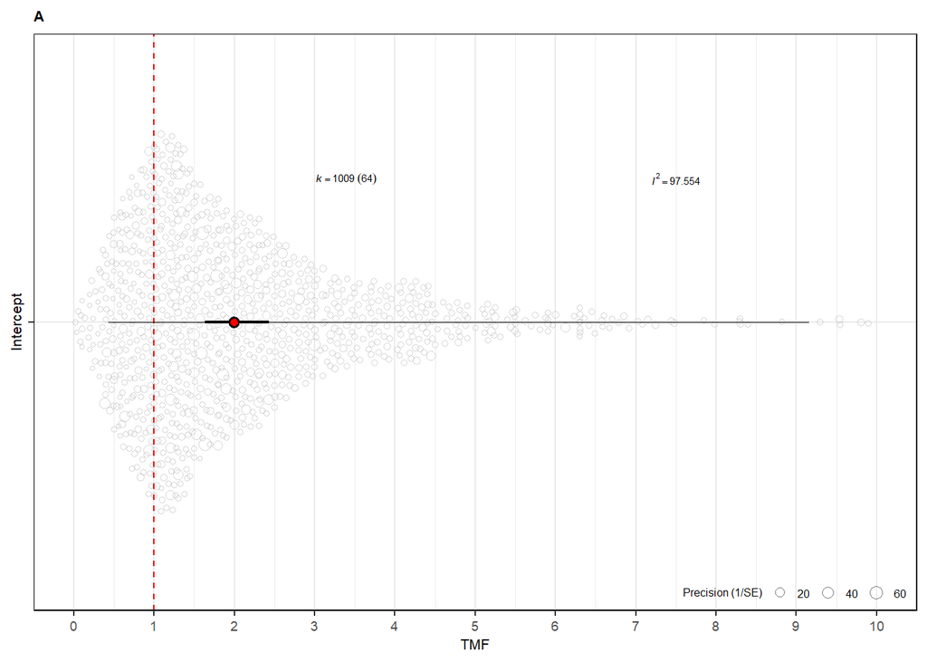

```r
I2 <- orchaRd::i2_ml(mod)
fig2A <- orchard_plot_new(mod,
                        transfm = "percent",
                        mod = "1",
                        group = "Study_ID",
                        xlab = "ln_TMF",
                        k.pos = "left",
                        alpha = 0.5,
                        trunk.size = 0.5,
                        branch.size = 0.8,
                        twig.size = 0.2,
                        colour = FALSE,
                        fill = FALSE) +
  annotate(geom = "text",
           x = 1.3,
           y = 7.5,
           label = paste0("italic(I)^{2} == ", round(I2[1],4)),
           size = 2,
           color ="black",
           parse = TRUE) +
  scale_size_continuous(range = c(1, 3)) + # change point scaling
  theme(panel.border = element_rect(colour = "black",
                                    fill = NA,
                                    size = 0.5), # border around the plot
        plot.title = element_text(face = "bold", size = 8),
       legend.title = element_text(size = 6),
        legend.text = element_text(size = 6),
       legend.key = element_blank(),
        legend.key.size = unit(0.3, "cm"),
        axis.title.x = element_text(size = 8),
        axis.title.y = element_text(size = 8),
        axis.text.y = element_blank(),
       axis.text.x = element_text(size = 7)) +
  #ylim(NA, 10) +
  xlab("Intercept") +
  ylab("TMF") +
  ggtitle("A") +
  scale_y_continuous(limits = c(0, 10), breaks = seq(0, 10, by = 1))

fig2A
```

```r
ggsave(here("figs","fig2A.png"),
       width = 8,
       height = 4)
```

# Terrestrial vs Aquatic

```r
mod_ecogroup <- rma.mv(
  yi = ln_TMF,
  V = VCV,
  mods = ~ Ecosystem_group, # Add Ecosystem_group as a moderator
  random = list(
    ~1 | Study_ID,
    ~1 | FW_ID,
    ~1 | PFAS_ID,
    ~1 | TMF_ID
  ),
  test = "t",
  sparse = TRUE,
  data = TMF_data2_ecogroups # Use the updated dataset
)

save(mod_ecogroup, file = here("Rmodels", "mod_ecogroup.RData"))
```

```r
load(here("Rmodels", "mod_ecogroup.RData"))
summary(mod_ecogroup)
```

```
##
## Multivariate Meta-Analysis Model (k = 1009; method: REML)
##
##     logLik    Deviance         AIC         BIC        AICc
## -1033.2121   2066.4242   2078.4242   2107.9126   2078.5082
##
## Variance Components:
##
##             estim    sqrt  nlvls  fixed    factor
## sigma^2.1  0.1748  0.4181     64     no  Study_ID
## sigma^2.2  0.0780  0.2793    117     no     FW_ID
## sigma^2.3  0.1787  0.4227     77     no   PFAS_ID
## sigma^2.4  0.1655  0.4068   1009     no    TMF_ID
##
## Test for Residual Heterogeneity:
## QE(df = 1007) = 25506.3451, p-val < .0001
##
## Test of Moderators (coefficient 2):
## F(df1 = 1, df2 = 1007) = 0.0394, p-val = 0.8428
##
## Model Results:
##
##                             estimate      se    tval    df    pval    ci.lb
## intrcpt                       0.6929  0.1045  6.6292  1007  <.0001   0.4878
## Ecosystem_groupTerrestrial    0.0491  0.2474  0.1984  1007  0.8428  -0.4365
##                              ci.ub
## intrcpt                     0.8980  ***
## Ecosystem_groupTerrestrial  0.5346
##
## ---
## Signif. codes:  0 '***' 0.001 '**' 0.01 '*' 0.05 '.' 0.1 ' ' 1
```

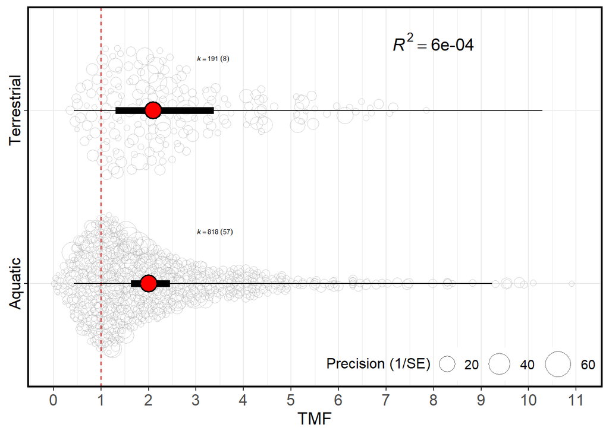

```r
r2_ecogroup <- r2_ml(mod_ecogroup, TMF_data2_ecogroups)

figS4 <- orchard_plot_new(
  mod_ecogroup,
  transfm = "percent",
  mod = "Ecosystem_group", # Specify the moderator
  group = "Study_ID",
  xlab = "ln_TMF",
  k.pos = "left",
  alpha = 0.6,
  trunk.size = 1.5,
  branch.size = 2.7,
  twig.size = 0.4,
  colour = FALSE,
  fill = FALSE
) +
  scale_size_continuous(range = c(1, 10)) +
  annotate(geom = "text",
           x = 2.4,
           y = 8,
           label = paste0("italic(R)^{2} == ", round(r2_ecogroup[1],4)),
           color ="black",
           parse = TRUE,
           size = 5) +
  theme(
    panel.border = element_rect(colour = "black", fill = NA, size = 1.3),
    #plot.title = element_text(face = "bold", size = 15),
    legend.title = element_text(size = 12),
    legend.text = element_text(size = 11),
    axis.title.x = element_text(size = 14),
    axis.title.y = element_blank(),
    axis.text.y = element_text(size = 13),
    axis.text.x = element_text(size = 13)
  ) +
  scale_y_continuous(limits = c(0, 11), breaks = seq(0, 11, by = 1)) +
  xlab("Intercept") +
  ylab("TMF")

figS4
```

# Subcategory meta-regression analysis

## mod_chem

```r
mod_chem <- rma.mv(ln_TMF ~ PFAS_ID - 1,
                   V = VCV_chem,
                   random = list(~ PFAS_ID | FW_ID),
                   struct = "DIAG",
                   test = "t", #to conunteract potential small sample size
                   sparse = T,
                   data = TMF_data3,
                   #verbose = TRUE,
                   control = list(iter.max = 1000,
                                  rel.tol = 1e-8))
# Save the model
save(mod_chem, file = here("Rmodels", "mod_chem.RData"))
# Save the table
write.csv(TMF_data3, here("Rdata/TMF_data3.csv"), row.names = FALSE)
```

```r
load(here("Rmodels", "mod_chem.RData"))
summary(mod_chem)
```

```
##
## Multivariate Meta-Analysis Model (k = 987; method: REML)
##
##     logLik    Deviance         AIC         BIC        AICc
## -2086.4586   4172.9172   4380.9172   4884.3341   4407.2305
##
## Variance Components:
##
## outer factor: FW_ID   (nlvls = 115)
## inner factor: PFAS_ID (nlvls = 52)
##
##              estim    sqrt  k.lvl  fixed          level
## tau^2.1     0.0107  0.1033      1     no  10:2 Cl-PFESA
## tau^2.2     0.0000  0.0000      2     no      10:2 FTSA
## tau^2.3     0.0107  0.1033      1     no      10:3 FTCA
## tau^2.4     0.0107  0.1033      1     no       4:2 FTSA
## tau^2.5     1.9336  1.3905      3     no      6:2 diPAP
## tau^2.6     0.9840  0.9920      4     no       6:2 FTSA
## tau^2.7     0.0000  0.0000      2     no    6:2 H-PFESA
## tau^2.8     0.0107  0.1033      1     no       7:3 FTCA
## tau^2.9     0.0107  0.1033      1     no        8:2 FTS
## tau^2.10    0.0000  0.0004      2     no       8:2 FTSA
## tau^2.11    0.0107  0.1033      1     no    8:2 H-PFESA
## tau^2.12    0.0000  0.0000      3     no          ADONA
## tau^2.13    0.0105  0.1027      1     no     cis-PFECHS
## tau^2.14    0.0107  0.1033      1     no       Cl-PFESA
## tau^2.15    1.4731  1.2137      6     no         EtFOSA
## tau^2.16    0.0107  0.1034      1     no        EtFOSAA
## tau^2.17    0.0537  0.2317     37     no          F-53B
## tau^2.18    0.0000  0.0000      2     no           FBSA
## tau^2.19    0.0105  0.1027      1     no          FHpPA
## tau^2.20    0.3753  0.6126     32     no           FOSA
## tau^2.21    0.0000  0.0049      2     no          FOSAA
## tau^2.22    0.6343  0.7965      2     no     H-PFMO2OSA
## tau^2.23    0.0000  0.0001      2     no        HFPO-DA
## tau^2.24    0.8068  0.8982      2     no       HFPO-TeA
## tau^2.25    0.1404  0.3747      3     no       HFPO-TrA
## tau^2.26    0.0001  0.0072      3     no        MeFOSAA
## tau^2.27    0.5642  0.7511      6     no       NEtFOSAA
## tau^2.28    0.5011  0.7079      4     no       NMeFOSAA
```

[output cut: 127 more lines]

```
## PFAS_IDPFMOAA
## PFAS_IDPFNA           ***
## PFAS_IDPFNOBS
## PFAS_IDPFNS            **
## PFAS_IDPFO5DoA        ***
## PFAS_IDPFOA             *
## PFAS_IDPFOS           ***
## PFAS_IDPFPeA
## PFAS_IDPFTeDA         ***
## PFAS_IDPFTrDA         ***
## PFAS_IDPFUnDA         ***
## PFAS_IDtrans-PFECHS
##
## ---
## Signif. codes:  0 '***' 0.001 '**' 0.01 '*' 0.05 '.' 0.1 ' ' 1
```

```r
res_tab1 <- broom::tidy(mod_chem)
```

```
## `height` was translated to `width`.
```

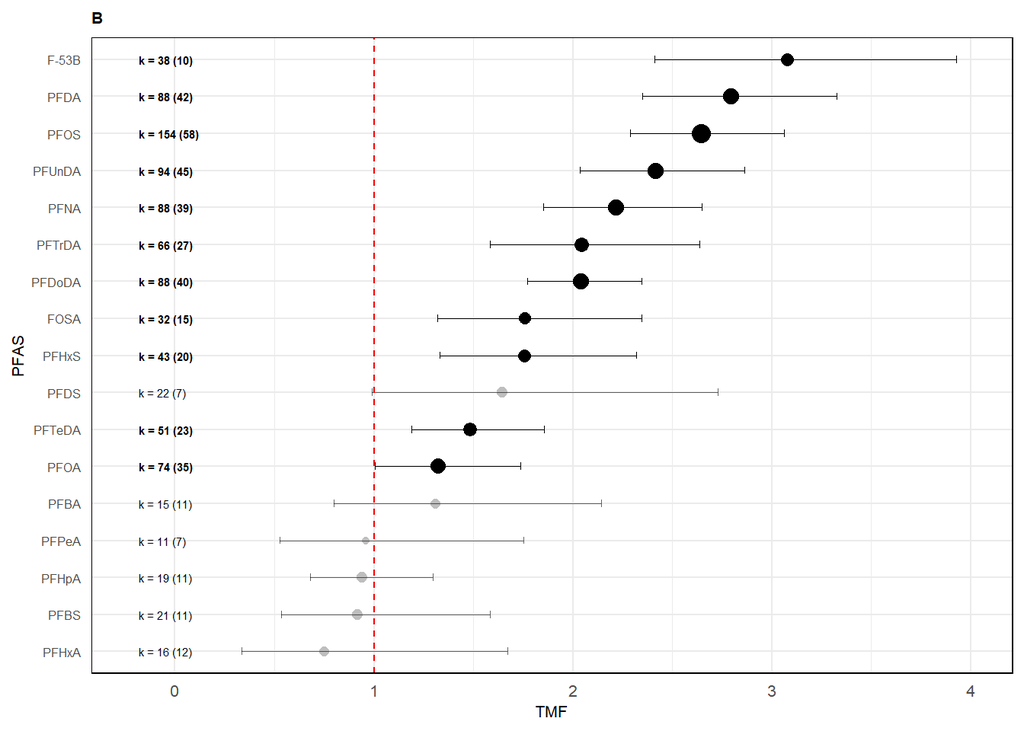

```r
res_tab1$ci.lb <- mod_chem$ci.lb
res_tab1$ci.ub <- mod_chem$ci.ub
res_tab1$pval <-mod_chem$pval
res_tab1 <- res_tab1 %>%
  mutate(
    PFAS_ID = str_remove(term, "^PFAS_ID"),  # Remove 'PFAS_ID1: ' prefix
    estimate = exp(estimate),  # Convert estimates back to original scale
    ci.lb = exp(ci.lb),  # Convert lower CI back to original scale
    ci.ub = exp(ci.ub)   # Convert upper CI back to original scale
  ) %>%
  arrange(PFAS_ID)

res_tab1 <- res_tab1 %>%
  mutate(k = k_n_data$k) %>%
  mutate(n = k_n_data$n)

# Prepare the data for plotting and order PFAS_ID by estimate value
plot_data1 <- res_tab1 %>%
  as.data.frame() %>%
  filter(k > 10) %>%
  arrange(estimate)

# Create the flipped forest plot
fig2B <- ggplot(plot_data1, aes(y = reorder(PFAS_ID, estimate), x = estimate)) +
  geom_point(aes(size = k),  # Make point size proportional to k
             color = ifelse(plot_data1$pval > 0.05, "grey", "black"),  # You can change the color if desired
             alpha = 1) +  # Add transparency for better visibility
  scale_size(range = c(1.5, 4)) + # Set minimum size to 3 and maximum to 6
  geom_errorbarh(aes(xmin = ci.lb, xmax = ci.ub),
                 height = 0.2,
                 size = 0.1,
                 alpha = ifelse(plot_data1$pval > 0.05, 0.6, 1)) +  # Horizontal error bars
  geom_vline(xintercept = 1, linetype = "dashed", color = "red", size = 0.4) +  # Reference line at 1
  geom_text(aes(label = paste0("k = ", k, " (", n, ")"), x = -0.18),
            hjust = 0, size = 2, # Add k values as text next to the points
            fontface = ifelse(plot_data1$pval < 0.05, "bold", "plain")) +  # Access pval outside aes()
  # Add "*" next to PFUnDA and PFNA
  # geom_text(data = subset(plot_data1, PFAS_ID %in% c("PFUnDA", "PFNA", "PFTrDA", "PFDoDA", "FOSA", "PFHxS", "PFDS", "PFTeDA", "PFOA", "PFBA", "PFPeA", "PFHpA", "PFBS", "PFHxA")),
  #           aes(x = -0.21, label = "*"), size = 9, color = "black") +
  # geom_text(data = subset(plot_data1, PFAS_ID %in% c("PFUnDA", "PFNA", "PFTrDA", "PFDoDA", "FOSA", "PFHxS", "PFDS", "PFTeDA", "PFOA", "PFBA", "PFPeA", "PFHpA", "PFBS", "PFHxA")),
  #           aes(x = ci.lb, label = "*"),
  #           hjust = 1.2, vjust = 0.7, size = 6, color = "black") +
  xlab("TMF") +
  ylab("PFAS") +
  ggtitle("B") +
  theme_minimal() +  # Use a minimal theme
  theme(legend.position = "none",
        panel.border = element_rect(colour = "black", fill = NA, size = 0.5),
         plot.title = element_text(face = "bold", size = 8),
       legend.title = element_text(size = 7),
        legend.text = element_text(size = 7),
        axis.title.x = element_text(size = 8),
        axis.title.y = element_text(size = 8),
        axis.text.y = element_text(size = 6),
       axis.text.x = element_text(size = 8)) +
   #scale_x_break(c(4, 6)) +
   scale_x_continuous(breaks = seq(0, 4, by = 1), limits = c(-0.21, 4))

fig2B
```

```r
# Combine plots with specified heights
fig2 <- fig2A / fig2B +
  plot_layout(heights = c(1, 2))

# Save the combined plot
ggsave(here("figs", "fig2.pdf"), plot = fig2, width = 160, height = 120, units = "mm", dpi = 600)

fig2B_data <- plot_data1 %>%
  select(PFAS_ID, k, n, estimate, std.error, statistic, p.value, ci.lb, ci.ub, pval)

write_csv(fig2B_data, here("Rdata", "fig2B_data.csv"))
```

```r
#mod_chem2 is identical to mod_chem but with the addition of an independent random factor (i.e., ~ 1 | TMF_ID).
mod_chem2 <- rma.mv(ln_TMF ~ PFAS_ID - 1,
                     V = VCV_chem,
                     random = list(~ PFAS_ID | FW_ID,
                                   ~ 1 | TMF_ID),
                     struct = "DIAG",
                     est = "t",
                     sparse = T,
                     data = TMF_data3,
                     #verbose = TRUE,
                     control=list(iter.max=1000,
                                  rel.tol=1e-8))

# Save the model
save(mod_chem2, file = here("Rdata", "mod_chem2.RData"))
```

## PFOS reference - Comparison model

# World map location of food webs

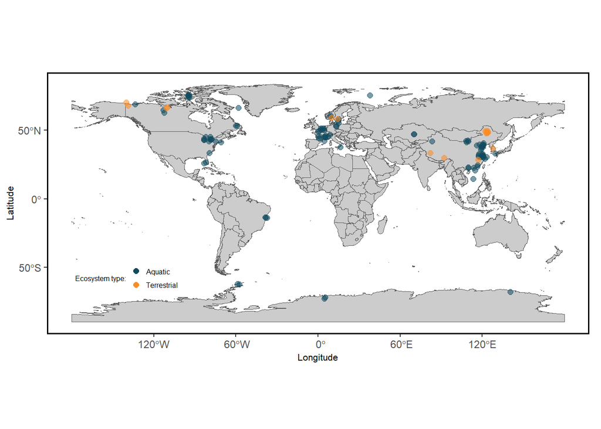

```r
# Formatting coordinates

coords <- fw_data %>%
  # Round Latitude and Longitude
  mutate(
    Latitude = round(Latitude_DD, 0),
    Longitude = round(Longitude_DD, 0)
  ) %>%
  mutate(Ecosystem = ifelse(Ecosystem == "terrestrial",
                                  "Terrestrial",
                                  "Aquatic"))

# Load the world map data
world <- ne_countries(scale = "medium", returnclass = "sf")

# Plot the map with clusters and counts
w_map <- ggplot(data = world) +
  geom_sf(fill = "grey80") +  # Plot the world map
  geom_jitter(data = coords, aes(x = Longitude, y = Latitude, color = Ecosystem, alpha = 0.7), size = 2, width = 1.2, height = 1.2) +
  theme(
    panel.background = element_rect(fill = "white"),
    panel.grid.major = element_blank(),
    panel.grid.minor = element_blank(),
    axis.title.x = element_text(size = 8),
    axis.title.y = element_text(size = 8),
    panel.border = element_rect(colour = "black", fill = NA, size = 1),
    plot.margin = margin(t = 10, r = 10, b = 5, l = 5),
    legend.position = c(0.04, 0.15),  # adjust these numbers to fine-tune location
    legend.justification = c(0, 0),
    legend.direction = "horizontal",  # Display the legend horizontally
    legend.background = element_rect(fill = "transparent", color = NA),
    legend.key = element_rect(fill = "transparent", color = NA),
    legend.key.size = unit(0.2, "cm"),
    legend.title = element_text(size = 6),
    legend.text = element_text(size = 6)) +
  guides(size = "none", alpha = "none", color = guide_legend(nrow = 2, byrow = TRUE, override.aes = list(size = 2))) +
  scale_color_manual(values = c("#114B5F", "#FB8B24")) +
  labs(color = "Ecosystem type:")

w_map
```

# Single-moderator meta-regression models

In our meta-analysis, we have 4 categories of predictors:

- Research methodological factors.
- Biological and environmental factors.
- Compounds’ physicochemical properties.
- Chemicals’ regulation status.

## Research methodological factors

### Sample type: whole-organism or organ/tissue-specific analysis

```r
sum(is.na(TMF_data2$Sample_type)) #checking the amount of NAs
#[1] 0
sample_model <- run_model(TMF_data2, ~ Sample_type -1)
save(sample_model, file = here("Rmodels", "sample_model.RData"))
```

```
##
## Multivariate Meta-Analysis Model (k = 1009; method: REML)
##
##     logLik    Deviance         AIC         BIC        AICc
## -1024.9436   2049.8871   2063.8871   2098.2833   2063.9994
##
## Variance Components:
##
##             estim    sqrt  nlvls  fixed    factor
## sigma^2.1  0.1751  0.4185     64     no  Study_ID
## sigma^2.2  0.0753  0.2744    117     no     FW_ID
## sigma^2.3  0.1800  0.4243     77     no   PFAS_ID
## sigma^2.4  0.1608  0.4010   1009     no    TMF_ID
##
## Test for Residual Heterogeneity:
## QE(df = 1006) = 24280.2706, p-val < .0001
##
## Test of Moderators (coefficients 1:3):
## F(df1 = 3, df2 = 1006) = 20.9900, p-val < .0001
##
## Model Results:
##
##                                                     estimate      se    tval
## Sample_typewhole-organisms \n only                    0.4981  0.1257  3.9621
## Sample_typespecific tissues                           0.6662  0.1480  4.5025
## Sample_typespecific tissues \n and whole-organisms    0.8998  0.1203  7.4797
##                                                       df    pval   ci.lb
## Sample_typewhole-organisms \n only                  1006  <.0001  0.2514
## Sample_typespecific tissues                         1006  <.0001  0.3758
## Sample_typespecific tissues \n and whole-organisms  1006  <.0001  0.6637
##                                                      ci.ub
## Sample_typewhole-organisms \n only                  0.7447  ***
## Sample_typespecific tissues                         0.9565  ***
## Sample_typespecific tissues \n and whole-organisms  1.1359  ***
##
## ---
## Signif. codes:  0 '***' 0.001 '**' 0.01 '*' 0.05 '.' 0.1 ' ' 1
```

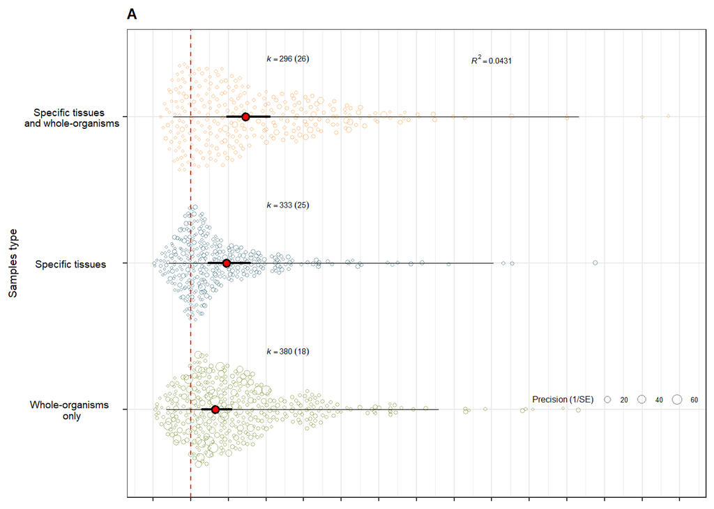

```
##
##    pred  ci.lb  ci.ub  pi.lb  pi.ub X.Sample_typewhole.organisms...only
##  1.4944 1.2159 1.8368 0.3259 6.8524                                  -1
##  X.Sample_typespecific.tissues
##                              0
##  X.Sample_typespecific.tissues...and.whole.organisms
##                                                    1
```

### Concentration determination method

```r
norm_model2 <- run_model(TMF_data2_norm, ~ Normalization)
save(norm_model2, file = here("Rmodels", "norm_model2.RData"))
```

```
##
## Multivariate Meta-Analysis Model (k = 945; method: REML)
##
##    logLik   Deviance        AIC        BIC       AICc
## -984.2558  1968.5116  1980.5116  2009.6060  1980.6013
##
## Variance Components:
##
##             estim    sqrt  nlvls  fixed    factor
## sigma^2.1  0.1745  0.4178     60     no  Study_ID
## sigma^2.2  0.0698  0.2642    113     no     FW_ID
## sigma^2.3  0.1783  0.4222     77     no   PFAS_ID
## sigma^2.4  0.1679  0.4097    945     no    TMF_ID
##
## Test for Residual Heterogeneity:
## QE(df = 943) = 24804.7664, p-val < .0001
##
## Test of Moderators (coefficient 2):
## F(df1 = 1, df2 = 943) = 17.5308, p-val < .0001
##
## Model Results:
##
##                              estimate      se    tval   df    pval   ci.lb
## intrcpt                        0.3708  0.1304  2.8445  943  0.0045  0.1150
## NormalizationNot normalized    0.3626  0.0866  4.1870  943  <.0001  0.1926
##                               ci.ub
## intrcpt                      0.6267   **
## NormalizationNot normalized  0.5325  ***
##
## ---
## Signif. codes:  0 '***' 0.001 '**' 0.01 '*' 0.05 '.' 0.1 ' ' 1
```

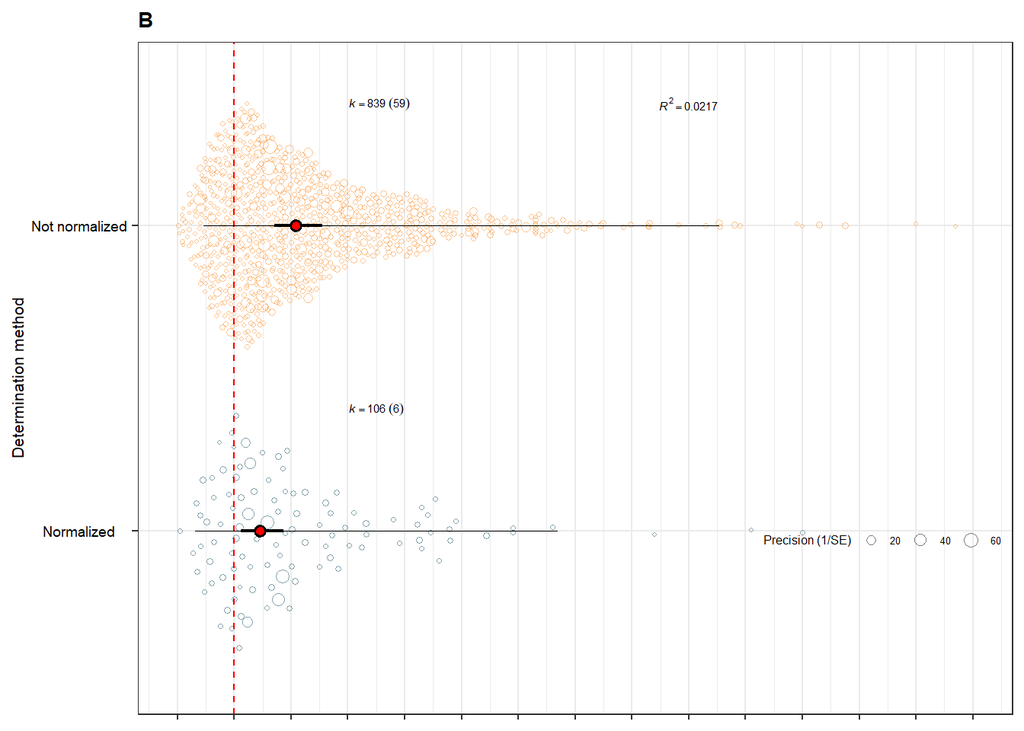

### Undetected strategy

```r
undetected_model <- run_model(TMF_data2_undetected_strategy2, ~ Censored_data_strategy -1)
save(undetected_model, file = here("Rmodels", "undetected_model.RData"))
```

```r
load(here("Rmodels", "undetected_model.RData"))
summary(undetected_model)
```

```
##
## Multivariate Meta-Analysis Model (k = 689; method: REML)
##
##    logLik   Deviance        AIC        BIC       AICc
## -728.8510  1457.7020  1475.7020  1516.4536  1475.9690
##
## Variance Components:
##
##             estim    sqrt  nlvls  fixed    factor
## sigma^2.1  0.2299  0.4795     40     no  Study_ID
## sigma^2.2  0.0326  0.1807     84     no     FW_ID
## sigma^2.3  0.3160  0.5622     58     no   PFAS_ID
## sigma^2.4  0.1990  0.4461    689     no    TMF_ID
##
## Test for Residual Heterogeneity:
## QE(df = 684) = 22922.4356, p-val < .0001
##
## Test of Moderators (coefficients 1:5):
## F(df1 = 5, df2 = 684) = 3.9983, p-val = 0.0014
##
## Model Results:
##
##                                                          estimate      se
## Censored_data_strategyOthers                               0.2759  0.3142
## Censored_data_strategyExclusion of data                    0.7829  0.3102
## Censored_data_strategyDivision by two \n or sqrt of two    0.6118  0.1644
## Censored_data_strategyRandom numbers                       0.5960  0.3223
## Censored_data_strategySubstitution with \n zero            0.5168  0.2988
##                                                            tval   df    pval
## Censored_data_strategyOthers                             0.8780  684  0.3802
## Censored_data_strategyExclusion of data                  2.5243  684  0.0118
## Censored_data_strategyDivision by two \n or sqrt of two  3.7220  684  0.0002
## Censored_data_strategyRandom numbers                     1.8491  684  0.0649
## Censored_data_strategySubstitution with \n zero          1.7295  684  0.0842
##                                                            ci.lb   ci.ub
## Censored_data_strategyOthers                             -0.3411  0.8929
## Censored_data_strategyExclusion of data                   0.1740  1.3919    *
## Censored_data_strategyDivision by two \n or sqrt of two   0.2891  0.9346  ***
## Censored_data_strategyRandom numbers                     -0.0369  1.2288    .
## Censored_data_strategySubstitution with \n zero          -0.0699  1.1035    .
##
## ---
## Signif. codes:  0 '***' 0.001 '**' 0.01 '*' 0.05 '.' 0.1 ' ' 1
```

```r
r2_lod <- r2_ml(undetected_model, TMF_data2_undetected_strategy2)

fig3D <- orchard_plot_new2(undetected_model,
             transfm = "percent",
             mod = "Censored_data_strategy",
             group = "Study_ID",
             xlab = "ln_TMF",
             legend.pos = "bottom.right",
             k.pos = "left",
             angle = 0,
             alpha = 0.5,
             colour = "black",
             fill = FALSE,
             trunk.size = 0.5,
             branch.size = 0.8,
             twig.size = 0.3) +
  annotate(geom = "text",
           x = 5.4,
           y = 9,
           label = paste0("italic(R)^{2} == ", round(r2_lod[1],4)),
           color ="black",
           parse = TRUE,
           size = 2) +
  #ggtitle("c)")+
  theme(plot.title = element_text(face = "bold", size  = 10),
       legend.title = element_text(size = 6),
        legend.text = element_text(size = 5),
        legend.position = c(1, 0.1),
       legend.key = element_blank(),
        legend.key.size = unit(0.3, "cm"),
        axis.title.x = element_text(size = 9),
        axis.title.y = element_text(size = 8),
        axis.text.y = element_text(size = 7),
       axis.text.x = element_text(size = 8)) +
  scale_size(range = c(0.5, 3)) +
  xlab("Treatment of undetected values") +
  ylab("TMF") +
  ggtitle("D") +
  scale_y_continuous(limits = c(0, 14), breaks = seq(0, 14, by = 1)) +
  scale_fill_manual(values = c("#F28482", "#66101F", "#597802", "#114B5F", "#FB8B24")) +
  scale_color_manual(values = c("#F28482", "#66101F", "#597802", "#114B5F", "#FB8B24"))
```

### N-isotope trophic enrichment factor (TEF)

```r
tef_model <- run_model(TMF_data2_tef, ~ TEF-1)
save(tef_model, file = here("Rmodels", "tef_model.RData"))
```

```r
load(here("Rmodels", "tef_model.RData"))
summary(tef_model)
```

```
##
## Multivariate Meta-Analysis Model (k = 739; method: REML)
##
##    logLik   Deviance        AIC        BIC       AICc
## -795.3823  1590.7646  1606.7646  1643.5635  1606.9629
##
## Variance Components:
##
##             estim    sqrt  nlvls  fixed    factor
## sigma^2.1  0.1928  0.4391     45     no  Study_ID
## sigma^2.2  0.0999  0.3160     79     no     FW_ID
## sigma^2.3  0.1277  0.3574     67     no   PFAS_ID
## sigma^2.4  0.1926  0.4389    739     no    TMF_ID
##
## Test for Residual Heterogeneity:
## QE(df = 735) = 20174.6203, p-val < .0001
##
## Test of Moderators (coefficients 1:4):
## F(df1 = 4, df2 = 735) = 12.1111, p-val < .0001
##
## Model Results:
##
##         estimate      se    tval   df    pval    ci.lb   ci.ub
## TEF2.3    0.3935  0.3367  1.1687  735  0.2429  -0.2675  1.0545
## TEF3.3    0.4224  0.5851  0.7220  735  0.4705  -0.7262  1.5710
## TEF3.4    0.8403  0.2017  4.1663  735  <.0001   0.4443  1.2362  ***
## TEF3.8    0.8052  0.1325  6.0774  735  <.0001   0.5451  1.0654  ***
##
## ---
## Signif. codes:  0 '***' 0.001 '**' 0.01 '*' 0.05 '.' 0.1 ' ' 1
```

```r
r2_tef <- r2_ml(tef_model, TMF_data2_tef)
   # R2_marginal R2_conditional
   #  0.04538842     0.88832187

fig3C <- orchard_plot_new2(tef_model,
                            transfm="percent",
             mod = "TEF",
             group = "Study_ID",
             xlab = "ln_TMF",
             legend.pos = "bottom.right",
             k.pos = "left",
             angle = 0,
             alpha = 0.5,
             colour = "black",
             fill = FALSE,
             trunk.size = 0.5,
             branch.size = 0.8,
             twig.size = 0.3) +
  annotate(geom = "text",
           x = 4.4,
           y = 9,
           label = paste0("italic(R)^{2} == ", round(r2_tef[1],4)),
           color ="black",
           parse = TRUE,
           size = 2) +
  #ggtitle("c)")+
  theme(plot.title = element_text(face = "bold", size  = 10),
        legend.title = element_text(size = 6),
        legend.text = element_text(size = 5),
        legend.position = c(1, 0.15),
        legend.key = element_blank(),
        legend.key.size = unit(0.3, "cm"),
        axis.title.x = element_blank(),
        axis.title.y = element_text(size = 8),
        axis.text.y = element_text(size = 7),
       axis.text.x = element_blank()) +
  scale_size(range = c(0.5, 3)) +
  xlab("Trophic Enrichment Factor") +
  ylab("TMF") +
  ggtitle("C") +
  scale_y_continuous(limits = c(0, 14), breaks = seq(0, 14, by = 1)) +
  scale_fill_manual(values = c("#66101F", "#597802", "#114B5F", "#FB8B24")) +
  scale_color_manual(values = c("#66101F", "#597802", "#114B5F", "#FB8B24"))
```

### TL vs δ15N

```r
rv_model <- run_model(TMF_data2_rv, ~ Regression_variable)
save(rv_model, file = here("Rmodels", "rv_model.RData"))
```

```r
load(here("Rmodels", "rv_model.RData"))
summary(rv_model)
```

```
##
## Multivariate Meta-Analysis Model (k = 976; method: REML)
##
##    logLik   Deviance        AIC        BIC       AICc
## -991.9299  1983.8599  1995.8599  2025.1483  1995.9467
##
## Variance Components:
##
##             estim    sqrt  nlvls  fixed    factor
## sigma^2.1  0.1516  0.3893     61     no  Study_ID
## sigma^2.2  0.0818  0.2861    113     no     FW_ID
## sigma^2.3  0.1896  0.4354     76     no   PFAS_ID
## sigma^2.4  0.1658  0.4072    976     no    TMF_ID
##
## Test for Residual Heterogeneity:
## QE(df = 974) = 25342.8813, p-val < .0001
##
## Test of Moderators (coefficient 2):
## F(df1 = 1, df2 = 974) = 6.2950, p-val = 0.0123
##
## Model Results:
##
##                          estimate      se     tval   df    pval    ci.lb
## intrcpt                    0.7443  0.1046   7.1131  974  <.0001   0.5390
## Regression_variableδ15N   -0.7402  0.2950  -2.5090  974  0.0123  -1.3191
##                            ci.ub
## intrcpt                   0.9497  ***
## Regression_variableδ15N  -0.1612    *
##
## ---
## Signif. codes:  0 '***' 0.001 '**' 0.01 '*' 0.05 '.' 0.1 ' ' 1
```

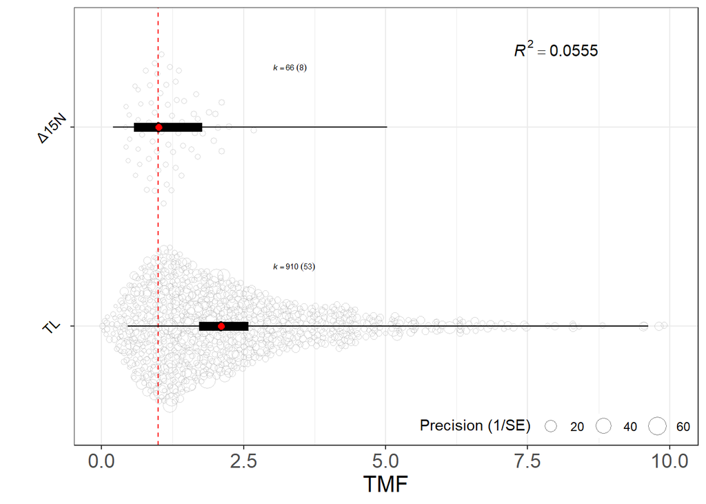

```r
r2_rv <- r2_ml(rv_model, TMF_data2_rv)

fig_rv <- orchard_plot_new(rv_model,
                            transfm="percent",
             mod = "Regression_variable",
             group = "Study_ID",
             xlab = "ln_TMF",
             legend.pos = "bottom.right",
             k.pos = "left",
             angle = 45,
             colour = "black",
             fill = FALSE,
             trunk.size = 0.6,
             branch.size = 3.1,
             twig.size = 0.5) +
  annotate(geom = "text",
           x = 2.4,
           y = 8,
           label = paste0("italic(R)^{2} == ", round(r2_rv[1],4)),
           color ="black",
           parse = TRUE,
           size = 4) +
  #ggtitle("c)")+
  theme(plot.title = element_text(size = 18),
       legend.title = element_text(size = 11),
        legend.text = element_text(size = 9),
        axis.title.x = element_text(size = 16),
        axis.title.y = element_text(size = 16),
        axis.text.y = element_text(size = 10),
       axis.text.x = element_text(size = 14)) +
  ylab("TMF") +
  ylim(NA, 10)

fig_rv
```

## Biological and environmental factors

### Latitude

```r
sum(is.na(TMF_data2$Latitude_abs)) #checking the amount of NAs
#[1] 0
lat_model <- run_model(TMF_data2, ~ scale(Latitude_abs))
save(lat_model, file = here("Rmodels", "lat_model.RData"))
```

```r
load(here("Rmodels", "lat_model.RData"))
summary(lat_model)
```

```
##
## Multivariate Meta-Analysis Model (k = 1009; method: REML)
##
##     logLik    Deviance         AIC         BIC        AICc
## -1032.8225   2065.6449   2077.6449   2107.1333   2077.7289
##
## Variance Components:
##
##             estim    sqrt  nlvls  fixed    factor
## sigma^2.1  0.1739  0.4170     64     no  Study_ID
## sigma^2.2  0.0785  0.2802    117     no     FW_ID
## sigma^2.3  0.1812  0.4257     76     no   PFAS_ID
## sigma^2.4  0.1652  0.4065   1009     no    TMF_ID
##
## Test for Residual Heterogeneity:
## QE(df = 1007) = 23157.5615, p-val < .0001
##
## Test of Moderators (coefficient 2):
## F(df1 = 1, df2 = 1007) = 0.0012, p-val = 0.9722
##
## Model Results:
##
##                      estimate      se    tval    df    pval    ci.lb   ci.ub
## intrcpt                0.6900  0.1017  6.7865  1007  <.0001   0.4905  0.8895
## scale(Latitude_abs)    0.0025  0.0729  0.0349  1007  0.9722  -0.1406  0.1457
##
## intrcpt              ***
## scale(Latitude_abs)
##
## ---
## Signif. codes:  0 '***' 0.001 '**' 0.01 '*' 0.05 '.' 0.1 ' ' 1
```

```r
r2_lat <- r2_ml(lat_model, TMF_data2)
   # R2_marginal R2_conditional
   #  0.00220226     0.74106678


lat_bubble <- orchaRd::mod_results(lat_model,
                                   mod = "Latitude_abs",
                                   group = "Study_ID")


fig5A <- bubble_plot_new(lat_bubble,
            mod = "Latitude_abs",
            group = "Study_ID",
            x = "Latitude_abs",
            y = "ln_TMF",
            est.lwd = 1,
            legend.pos = "bottom.right",
            k.pos = "bottom.left",
            ci.col = "red",
            pi.col = "black",
            est.col = "black",
            g = TRUE) +
  geom_point(data = TMF_data2, aes(x = Latitude_abs,
                                   y = ln_TMF,
                                   size = 1/ln_TMF_se),
             color = "#597802",
             alpha = 0.2) +
  annotate(geom ="text",
           x = 57,
           y = 3.1,
           label = paste0("italic(R)^{2} == ", round(r2_lat[1],4)),
           color = "black",
           parse = TRUE,
           size = 2) +
  #ggtitle("a)") +
  theme(plot.title = element_text(face = "bold", size = 9),
        legend.title = element_text(size = 6),
        legend.text = element_text(size = 6),
        legend.key = element_blank(),
        legend.key.size = unit(0.3, "cm"),
        axis.title.x = element_text(size = 8),
        axis.title.y = element_text(size = 8),
        axis.text.y = element_text(size = 7),
        axis.text.x = element_text(size = 7)) +
  scale_size(range = c(0.5, 3)) +
  ggtitle("A") +
  xlab("Latitude (absolute value)") +
  ylab("ln TMF")
```

### Geographic location

```r
location_model <- run_model(TMF_data2_loc, ~ Location - 1)
save(location_model, file = here("Rmodels", "location_model.RData"))
```

```r
load(here("Rmodels", "location_model.RData"))
summary(location_model)
```

```
##
## Multivariate Meta-Analysis Model (k = 970; method: REML)
##
##    logLik   Deviance        AIC        BIC       AICc
## -977.0269  1954.0538  1972.0538  2015.9030  1972.2423
##
## Variance Components:
##
##             estim    sqrt  nlvls  fixed    factor
## sigma^2.1  0.1685  0.4105     61     no  Study_ID
## sigma^2.2  0.0779  0.2791    112     no     FW_ID
## sigma^2.3  0.1977  0.4447     73     no   PFAS_ID
## sigma^2.4  0.1554  0.3942    970     no    TMF_ID
##
## Test for Residual Heterogeneity:
## QE(df = 965) = 17065.0131, p-val < .0001
##
## Test of Moderators (coefficients 1:5):
## F(df1 = 5, df2 = 965) = 9.2808, p-val < .0001
##
## Model Results:
##
##                           estimate      se    tval   df    pval    ci.lb
## LocationAntarctic Region    0.6581  0.3491  1.8850  965  0.0597  -0.0270
## LocationArctic Region       0.9797  0.4037  2.4266  965  0.0154   0.1874
## LocationEast Asia           0.7697  0.1409  5.4611  965  <.0001   0.4931
## LocationEurope              0.5326  0.1770  3.0099  965  0.0027   0.1854
## LocationNorth America       0.6944  0.1637  4.2427  965  <.0001   0.3732
##                            ci.ub
## LocationAntarctic Region  1.3433    .
## LocationArctic Region     1.7721    *
## LocationEast Asia         1.0463  ***
## LocationEurope            0.8799   **
## LocationNorth America     1.0156  ***
##
## ---
## Signif. codes:  0 '***' 0.001 '**' 0.01 '*' 0.05 '.' 0.1 ' ' 1
```

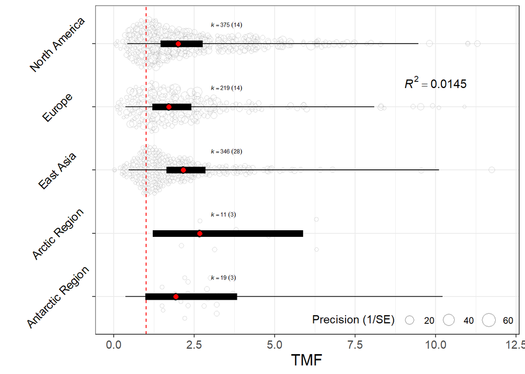

```r
r2_location <- r2_ml(location_model, TMF_data2_loc)


figS2 <- orchard_plot_new(location_model,
                        transfm="percent",
             mod = "Location",
             group = "Study_ID",
             xlab = "ln_TMF",
             legend.pos = "bottom.right",
             k.pos = "left",
             angle = 45,
             colour = "black",
             fill = FALSE,
             trunk.size = 0.6,
             branch.size = 3.1,
             twig.size = 0.5) +
  annotate(geom = "text",
           x = 4.4,
           y = 10,
           label = paste0("italic(R)^{2} == ", round(r2_location[1],4)),
           color ="black",
           parse = TRUE,
           size = 4) +
  #ggtitle("c)")+
  theme(plot.title = element_text(size = 18),
       legend.title = element_text(size = 11),
        legend.text = element_text(size = 9),
        axis.title.x = element_text(size = 15),
        axis.title.y = element_text(size = 15),
        axis.text.y = element_text(size = 11),
       axis.text.x = element_text(size = 11)) +
  ylab("TMF") +
  ylim(NA, 12)

figS2
```

```r
#predict.rma(location_model, newmods = c(-1, 0, 1, 0), transf = exp, addx = T)
#predict.rma(location_model, newmods = c(0, -1, 1, 0), transf = exp, addx = T)
```

### Type of breathing - top predator

```r
breath_model <- run_model(TMF_data2_bt, ~ Breathing_type)
save(breath_model, file = here("Rmodels", "breath_model.RData"))
```

```r
load(here("Rmodels", "breath_model.RData"))
summary(breath_model)
```

```
##
## Multivariate Meta-Analysis Model (k = 858; method: REML)
##
##    logLik   Deviance        AIC        BIC       AICc
## -863.9409  1727.8817  1739.8817  1768.3953  1739.9807
##
## Variance Components:
##
##             estim    sqrt  nlvls  fixed    factor
## sigma^2.1  0.2997  0.5475     53     no  Study_ID
## sigma^2.2  0.0000  0.0001     97     no     FW_ID
## sigma^2.3  0.2252  0.4746     75     no   PFAS_ID
## sigma^2.4  0.0918  0.3031    858     no    TMF_ID
##
## Test for Residual Heterogeneity:
## QE(df = 856) = 2082.9747, p-val < .0001
##
## Test of Moderators (coefficient 2):
## F(df1 = 1, df2 = 856) = 6.5976, p-val = 0.0104
##
## Model Results:
##
##                                estimate      se     tval   df    pval    ci.lb
## intrcpt                          1.0230  0.1837   5.5674  856  <.0001   0.6623
## Breathing_typeWater breathing   -0.5051  0.1966  -2.5686  856  0.0104  -0.8910
##                                  ci.ub
## intrcpt                         1.3836  ***
## Breathing_typeWater breathing  -0.1191    *
##
## ---
## Signif. codes:  0 '***' 0.001 '**' 0.01 '*' 0.05 '.' 0.1 ' ' 1
```

```r
r2_breath <- r2_ml(breath_model, TMF_data2_bt)


fig4A <- orchard_plot_new2(breath_model,
                               transfm="percent",
             mod = "Breathing_type",
             group = "Study_ID",
             xlab = "ln_TMF",
             legend.pos = "bottom.right",
             k.pos = "left",
             angle = 0,
             alpha = 0.4,
             colour = "black",
             fill = FALSE,
             trunk.size = 0.4,
             branch.size = 0.7,
             twig.size = 0.2) +
  annotate(geom = "text",
           x = 2.4,
           y = 9,
           label = paste0("italic(R)^{2} == ", round(r2_breath[1],4)),
           color ="black",
           parse = TRUE,
           size = 1.8) +
  #ggtitle("c)")+
  theme(plot.title = element_text(face = "bold", size  = 8),
        legend.title = element_text(size = 5),
        legend.text = element_text(size = 5),
        legend.position = c(1, 0.3),
        legend.key = element_blank(),
        legend.key.size = unit(0.3, "cm"),
        axis.title.x = element_blank(),
        axis.title.y = element_text(size = 7),
        axis.text.y = element_text(size = 6),
       axis.text.x = element_blank()) +
  scale_size(range = c(0.5, 3)) +
  xlab("Top predator") +
  ylab("TMF") +
  ggtitle("B") +
  #scale_y_break(c(11, 13)) +
  scale_y_continuous(limits = c(0, 14), breaks = seq(0, 14, by = 1)) +
  scale_fill_manual(values = c("#F28482", "#66101F", "#597802", "#114B5F", "#FB8B24")) +
  scale_color_manual(values = c("#F28482", "#66101F", "#597802", "#114B5F", "#FB8B24"))
```

### Marine vs freshwater

```r
sum(is.na(TMF_data2_aquatic$Ecosystem)) #checking the amount of NAs
#[1] 0
eco_aq_model <- run_model(TMF_data2_aquatic, ~ Ecosystem)
save(eco_aq_model, file = here("Rmodels", "eco_aq_model.RData"))
```

```r
load(here("Rmodels", "eco_aq_model.RData"))
summary(eco_aq_model)
```

```
##
## Multivariate Meta-Analysis Model (k = 637; method: REML)
##
##    logLik   Deviance        AIC        BIC       AICc
## -684.6456  1369.2913  1381.2913  1408.0130  1381.4250
##
## Variance Components:
##
##             estim    sqrt  nlvls  fixed    factor
## sigma^2.1  0.2091  0.4573     47     no  Study_ID
## sigma^2.2  0.0853  0.2920     83     no     FW_ID
## sigma^2.3  0.1761  0.4197     70     no   PFAS_ID
## sigma^2.4  0.1650  0.4062    637     no    TMF_ID
##
## Test for Residual Heterogeneity:
## QE(df = 635) = 9722.2356, p-val < .0001
##
## Test of Moderators (coefficient 2):
## F(df1 = 1, df2 = 635) = 1.9856, p-val = 0.1593
##
## Model Results:
##
##                      estimate      se     tval   df    pval    ci.lb   ci.ub
## intrcpt                0.8936  0.1624   5.5028  635  <.0001   0.5747  1.2124
## Ecosystemfreshwater   -0.2770  0.1966  -1.4091  635  0.1593  -0.6631  0.1090
##
## intrcpt              ***
## Ecosystemfreshwater
##
## ---
## Signif. codes:  0 '***' 0.001 '**' 0.01 '*' 0.05 '.' 0.1 ' ' 1
```

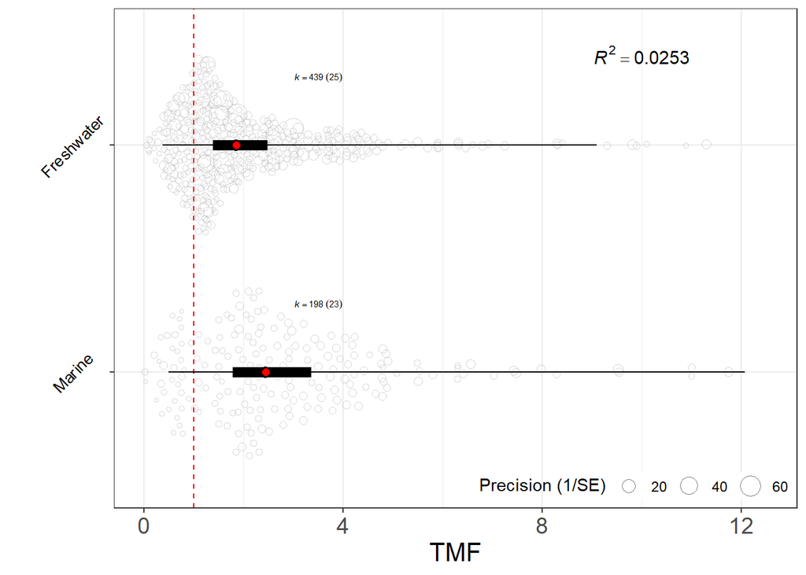

```r
r2_eco_aq <- r2_ml(eco_aq_model, TMF_data2_aquatic)

figS5 <- orchard_plot_new(eco_aq_model,
                            transfm="percent",
                            mod = "Ecosystem",
                            group = "Study_ID",
                            xlab = "ln_TMF",
                            legend.pos = "bottom.right",
                            k.pos = "left",
                            angle = 45,
                            colour = "black",
                            fill = FALSE,
                            trunk.size = 0.6,
                            branch.size = 3.1,
                            twig.size = 0.5) +
  annotate(geom = "text",
           x = 2.4,
           y = 10,
           label = paste0("italic(R)^{2} == ", round(r2_eco_aq[1],4)),
           color ="black",
           parse = TRUE,
           size = 4) +
  #ggtitle("c)")+
  theme(plot.title = element_text(size = 18),
       legend.title = element_text(size = 11),
        legend.text = element_text(size = 9),
        axis.title.x = element_text(size = 16),
        axis.title.y = element_text(size = 16),
        axis.text.y = element_text(size = 10),
       axis.text.x = element_text(size = 14)) +
  ylab("TMF") +
  ylim(NA, 12.5)

figS5
```

### Type of breathing - food web

```r
bt_fw_model <- run_model(TMF_data2, ~ Breathing_type_fw)
save(bt_fw_model, file = here("Rmodels", "bt_fw_model.RData"))
```

```r
load(here("Rmodels", "bt_fw_model.RData"))
summary(bt_fw_model)
```

```
##
## Multivariate Meta-Analysis Model (k = 1009; method: REML)
##
##     logLik    Deviance         AIC         BIC        AICc
## -1030.5495   2061.0990   2073.0990   2102.5874   2073.1830
##
## Variance Components:
##
##             estim    sqrt  nlvls  fixed    factor
## sigma^2.1  0.1976  0.4445     64     no  Study_ID
## sigma^2.2  0.0546  0.2337    117     no     FW_ID
## sigma^2.3  0.1787  0.4227     77     no   PFAS_ID
## sigma^2.4  0.1654  0.4066   1009     no    TMF_ID
##
## Test for Residual Heterogeneity:
## QE(df = 1007) = 25579.9740, p-val < .0001
##
## Test of Moderators (coefficient 2):
## F(df1 = 1, df2 = 1007) = 6.2129, p-val = 0.0128
##
## Model Results:
##
##                                           estimate      se     tval    df
## intrcpt                                     0.7490  0.1036   7.2317  1007
## Breathing_type_fwwater breathing \n only   -0.6512  0.2613  -2.4926  1007
##                                             pval    ci.lb    ci.ub
## intrcpt                                   <.0001   0.5457   0.9522  ***
## Breathing_type_fwwater breathing \n only  0.0128  -1.1639  -0.1385    *
##
## ---
## Signif. codes:  0 '***' 0.001 '**' 0.01 '*' 0.05 '.' 0.1 ' ' 1
```

```r
r2_bt_fw <- r2_ml(bt_fw_model, TMF_data2)

fig4B <- orchard_plot_new2(bt_fw_model,
            transfm="percent",
             mod = "Breathing_type_fw",
             group = "Study_ID",
             xlab = "ln_TMF",
             legend.pos = "bottom.right",
             k.pos = "left",
             angle = 0,
            alpha = 0.4,
             colour = "black",
             fill = FALSE,
             trunk.size = 0.4,
             branch.size = 0.7,
             twig.size = 0.2) +
  annotate(geom = "text",
           x = 2.4,
           y = 9,
           label = paste0("italic(R)^{2} == ", round(r2_bt_fw[1],4)),
           color ="black",
           parse = TRUE,
           size = 1.8) +
  #ggtitle("c)")+
  theme(plot.title = element_text(face = "bold", size  = 8),
        legend.title = element_text(size = 5),
        legend.text = element_text(size = 5),
        legend.position = c(1, 0.3),
        legend.key = element_blank(),
        legend.key.size = unit(0.3, "cm"),
        axis.title.x = element_blank(),
        axis.title.y = element_text(size = 7),
        axis.text.y = element_text(size = 6),
       axis.text.x = element_blank()) +
  scale_size(range = c(0.5, 3)) +
  xlab("Organisms") +
  ylab("TMF") +
  ggtitle("A") +
  #scale_y_break(c(11, 13)) +
  scale_y_continuous(limits = c(0, 14), breaks = seq(0, 14, by = 1)) +
  scale_fill_manual(values = c("#114B5F", "#FB8B24")) +
  scale_color_manual(values = c("#114B5F", "#FB8B24")) #+
 # scale_y_break(c(11, 13))
```

### Trophic position of the food web baseline

```r
TL_lowest_model <- run_model(TMF_data2_TL_lowest, ~scale(TL_lowest))
save(TL_lowest_model, file = here("Rmodels", "TL_lowest_model.RData"))
```

```r
load(here("Rmodels", "TL_lowest_model.RData"))
summary(TL_lowest_model)
```

```
##
## Multivariate Meta-Analysis Model (k = 841; method: REML)
##
##    logLik   Deviance        AIC        BIC       AICc
## -861.8727  1723.7454  1735.7454  1764.1387  1735.8464
##
## Variance Components:
##
##             estim    sqrt  nlvls  fixed    factor
## sigma^2.1  0.1634  0.4043     52     no  Study_ID
## sigma^2.2  0.0764  0.2764     95     no     FW_ID
## sigma^2.3  0.1799  0.4241     69     no   PFAS_ID
## sigma^2.4  0.1595  0.3994    841     no    TMF_ID
##
## Test for Residual Heterogeneity:
## QE(df = 839) = 21807.1305, p-val < .0001
##
## Test of Moderators (coefficient 2):
## F(df1 = 1, df2 = 839) = 1.7794, p-val = 0.1826
##
## Model Results:
##
##                   estimate      se     tval   df    pval    ci.lb   ci.ub
## intrcpt             0.7906  0.1083   7.2984  839  <.0001   0.5780  1.0032  ***
## scale(TL_lowest)   -0.0864  0.0647  -1.3339  839  0.1826  -0.2135  0.0407
##
## ---
## Signif. codes:  0 '***' 0.001 '**' 0.01 '*' 0.05 '.' 0.1 ' ' 1
```

```r
r2_TL_lowest <- r2_ml(TL_lowest_model, TMF_data2_TL_lowest)
   # R2_marginal R2_conditional
   #  0.02422045     0.88474369


TL_lowest_bubble <- orchaRd::mod_results(TL_lowest_model,
                                   mod = "TL_lowest",
                                   group = "Study_ID")


fig5B <- bubble_plot_new(TL_lowest_bubble,
            mod = "TL_lowest",
            group = "Study_ID",
            x = "TL_lowest",
            y = "ln_TMF",
            est.lwd = 1,
            legend.pos = "bottom.right",
            k.pos = "bottom.left",
            ci.col = "red",
            pi.col = "black",
            est.col = "black",
            g = TRUE) +
  geom_point(data = TMF_data2, aes(x = TL_lowest,
                                   y = ln_TMF,
                                   size = 1/ln_TMF_se),
             color = "#114B5F",
             alpha = 0.2) +
  annotate(geom ="text",
           x = 3.1,
           y = 3.1,
           label = paste0("italic(R)^{2} == ", round(r2_TL_lowest[1],4)),
           color = "black",
           parse = TRUE,
           size = 2) +
  #ggtitle("a)") +
  theme(plot.title = element_text(face = "bold", size = 9),
        legend.title = element_text(size = 6),
        legend.text = element_text(size = 6),
        legend.key = element_blank(),
        legend.key.size = unit(0.3, "cm"),
        axis.title.x = element_text(size = 8),
        axis.title.y = element_blank(),
        axis.text.y = element_blank(),
        axis.text.x = element_text(size = 7)) +
  scale_size(range = c(0.5, 3)) +
  ggtitle("B") +
  xlab("Trophic level of the baseline organism") +
  ylab("ln TMF")
```

### Trophic position of the top predator

```r
TL_highest_model <- run_model(TMF_data2_TL_highest, ~scale(TL_highest))
save(TL_highest_model, file = here("Rmodels", "TL_highest_model.RData"))
```

```r
load(here("Rmodels", "TL_highest_model.RData"))
summary(TL_highest_model)
```

```
##
## Multivariate Meta-Analysis Model (k = 841; method: REML)
##
##    logLik   Deviance        AIC        BIC       AICc
## -862.7096  1725.4191  1737.4191  1765.8124  1737.5201
##
## Variance Components:
##
##             estim    sqrt  nlvls  fixed    factor
## sigma^2.1  0.1457  0.3817     52     no  Study_ID
## sigma^2.2  0.0895  0.2991     95     no     FW_ID
## sigma^2.3  0.1789  0.4230     69     no   PFAS_ID
## sigma^2.4  0.1590  0.3988    841     no    TMF_ID
##
## Test for Residual Heterogeneity:
## QE(df = 839) = 21140.6323, p-val < .0001
##
## Test of Moderators (coefficient 2):
## F(df1 = 1, df2 = 839) = 0.1455, p-val = 0.7030
##
## Model Results:
##
##                    estimate      se     tval   df    pval    ci.lb   ci.ub
## intrcpt              0.7871  0.1072   7.3447  839  <.0001   0.5768  0.9975  ***
## scale(TL_highest)   -0.0231  0.0606  -0.3814  839  0.7030  -0.1421  0.0959
##
## ---
## Signif. codes:  0 '***' 0.001 '**' 0.01 '*' 0.05 '.' 0.1 ' ' 1
```

```r
r2_TL_highest <- r2_ml(TL_highest_model, TMF_data2_TL_highest)

TL_highest_bubble <- orchaRd::mod_results(TL_highest_model,
                                   mod = "TL_highest",
                                   group = "Study_ID")

fig5C <- bubble_plot_new(TL_highest_bubble,
            mod = "TL_highest",
            group = "Study_ID",
            x = "TL_highest",
            y = "ln_TMF",
            est.lwd = 1,
            legend.pos = "bottom.right",
            k.pos = "bottom.left",
            ci.col = "red",
            pi.col = "black",
            est.col = "black",
            g = TRUE) +
  geom_point(data = TMF_data2, aes(x = TL_highest,
                                   y = ln_TMF,
                                   size = 1/ln_TMF_se),
             color = "#66101F",
             alpha = 0.2) +
  annotate(geom ="text",
           x = 5,
           y = 3.1,
           label = paste0("italic(R)^{2} == ", round(r2_TL_highest[1],4)),
           color = "black",
           parse = TRUE,
           size = 2) +
  #ggtitle("a)") +
  theme(plot.title = element_text(face = "bold", size = 9),
        legend.title = element_text(size = 6),
        legend.text = element_text(size = 6),
        legend.key = element_blank(),
        legend.key.size = unit(0.3, "cm"),
        axis.title.x = element_text(size = 8),
        axis.title.y = element_text(size = 8),
        axis.text.y = element_text(size = 7),
        axis.text.x = element_text(size = 7)) +
  scale_size(range = c(0.5, 3)) +
  ggtitle("C") +
  xlab("Trophic level of the top predator") +
  ylab("ln TMF")
```

### Food web length

```r
fw_length_model <- run_model(TMF_data2_fw_length, ~scale(fw_length)-1)
save(fw_length_model, file = here("Rmodels", "fw_length_model.RData"))
```

```r
load(here("Rmodels", "fw_length_model.RData"))
summary(fw_length_model)
```

[output not shown]

```r
r2_fw_length <- r2_ml(fw_length_model, TMF_data2_fw_length)
   # R2_marginal R2_conditional
   #  0.02422045     0.88474369


fw_length_bubble <- orchaRd::mod_results(fw_length_model,
                                   mod = "fw_length",
                                   group = "Study_ID")


fig5D <- bubble_plot_new(fw_length_bubble,
            mod = "fw_length",
            group = "Study_ID",
            x = "fw_length",
            y = "ln_TMF",
            est.lwd = 1,
            legend.pos = "bottom.right",
            k.pos = "bottom.left",
            ci.col = "red",
            pi.col = "black",
            est.col = "black",
            g = TRUE) +
  geom_point(data = TMF_data2, aes(x = fw_length,
                                   y = ln_TMF,
                                   size = 1/ln_TMF_se),
             color = "#F28482",
             alpha = 0.2) +
  annotate(geom ="text",
           x = 3.5,
           y = 3.1,
           label = paste0("italic(R)^{2} == ", round(r2_fw_length[1],4)),
           color = "black",
           parse = TRUE,
           size = 2) +
  #ggtitle("a)") +
  theme(plot.title = element_text(face = "bold", size = 9),
        legend.title = element_text(size = 6),
        legend.text = element_text(size = 6),
        legend.key = element_blank(),
        legend.key.size = unit(0.3, "cm"),
        axis.title.x = element_text(size = 8),
        axis.title.y = element_blank(),
        axis.text.y = element_blank(),
        axis.text.x = element_text(size = 7)) +
  scale_size(range = c(0.5, 3)) +
  ggtitle("D") +
  xlab("Number of trophic levels") +
  ylab("ln TMF")
```

## Compounds’ physicochemical properties

### Carbon chain length

```r
ccl_model <- run_model(TMF_data2_ccl, ~scale(ccl))
save(ccl_model, file = here("Rmodels", "ccl_model.RData"))
```

```r
load(here("Rmodels", "ccl_model.RData"))
summary(ccl_model)
```

```
##
## Multivariate Meta-Analysis Model (k = 986; method: REML)
##
##     logLik    Deviance         AIC         BIC        AICc
## -1006.6435   2013.2870   2025.2870   2054.6367   2025.3730
##
## Variance Components:
##
##             estim    sqrt  nlvls  fixed    factor
## sigma^2.1  0.1699  0.4122     62     no  Study_ID
## sigma^2.2  0.0786  0.2804    115     no     FW_ID
## sigma^2.3  0.1981  0.4451     71     no   PFAS_ID
## sigma^2.4  0.1665  0.4080    986     no    TMF_ID
##
## Test for Residual Heterogeneity:
## QE(df = 984) = 24459.3901, p-val < .0001
##
## Test of Moderators (coefficient 2):
## F(df1 = 1, df2 = 984) = 0.5561, p-val = 0.4560
##
## Model Results:
##
##             estimate      se    tval   df    pval    ci.lb   ci.ub
## intrcpt       0.6979  0.1062  6.5726  984  <.0001   0.4896  0.9063  ***
## scale(ccl)    0.0499  0.0670  0.7457  984  0.4560  -0.0815  0.1814
##
## ---
## Signif. codes:  0 '***' 0.001 '**' 0.01 '*' 0.05 '.' 0.1 ' ' 1
```

```r
r2_ccl <- r2_ml(ccl_model, TMF_data2_ccl)

ccl_bubble <- orchaRd::mod_results(ccl_model,
                                   mod = "ccl",
                                   group = "Study_ID")


fig5E <- bubble_plot_new(ccl_bubble,
            mod = "ccl",
            group = "Study_ID",
            x = "ccl",
            y = "ln_TMF",
            est.lwd = 1,
            legend.pos = "bottom.right",
            k.pos = "bottom.left",
            ci.col = "red",
            pi.col = "black",
            est.col = "black",
            g = TRUE) +
  geom_point(data = TMF_data2, aes(x = ccl,
                                   y = ln_TMF,
                                   size = 1/ln_TMF_se),
             color = "#DDC9B4",
             alpha = 0.2) +
  annotate(geom ="text",
           x = 12,
           y = 3,
           label = paste0("italic(R)^{2} == ", round(r2_ccl[1],4)),
           color = "black",
           parse = TRUE,
           size = 2) +
  ggtitle("E") +
  theme(plot.title = element_text(face = "bold", size = 9),
        legend.title = element_text(size = 6),
        legend.text = element_text(size = 6),
        legend.key = element_blank(),
        legend.key.size = unit(0.3, "cm"),
        axis.title.x = element_text(size = 8),
        axis.title.y = element_text(size = 8),
        axis.text.y = element_text(size = 7),
        axis.text.x = element_text(size = 7)) +
  scale_size(range = c(0.5, 3)) +
  xlab("Carbon chain length") +
  ylab("ln TMF") +
  scale_x_continuous(limits = c(3, 15), breaks = seq(3, 15, by = 3))
```

### Perfluoroalkyl chain length

```r
p_ccl_model <- run_model(TMF_data2_p_ccl, ~scale(perfluoroalkyl_ccl))
save(p_ccl_model, file = here("Rmodels", "p_ccl_model.RData"))
```

```r
load(here("Rmodels", "p_ccl_model.RData"))
summary(p_ccl_model)
```

```
##
## Multivariate Meta-Analysis Model (k = 979; method: REML)
##
##     logLik    Deviance         AIC         BIC        AICc
## -1002.4641   2004.9282   2016.9282   2046.2352   2017.0148
##
## Variance Components:
##
##             estim    sqrt  nlvls  fixed    factor
## sigma^2.1  0.1730  0.4159     62     no  Study_ID
## sigma^2.2  0.0770  0.2775    115     no     FW_ID
## sigma^2.3  0.1947  0.4413     71     no   PFAS_ID
## sigma^2.4  0.1679  0.4098    979     no    TMF_ID
##
## Test for Residual Heterogeneity:
## QE(df = 977) = 24457.1690, p-val < .0001
##
## Test of Moderators (coefficient 2):
## F(df1 = 1, df2 = 977) = 1.3892, p-val = 0.2388
##
## Model Results:
##
##                            estimate      se    tval   df    pval    ci.lb
## intrcpt                      0.7020  0.1059  6.6279  977  <.0001   0.4942
## scale(perfluoroalkyl_ccl)    0.0762  0.0647  1.1787  977  0.2388  -0.0507
##                             ci.ub
## intrcpt                    0.9099  ***
## scale(perfluoroalkyl_ccl)  0.2032
##
## ---
## Signif. codes:  0 '***' 0.001 '**' 0.01 '*' 0.05 '.' 0.1 ' ' 1
```

```
## Ignoring unknown labels:
## • parse : "TRUE"
```

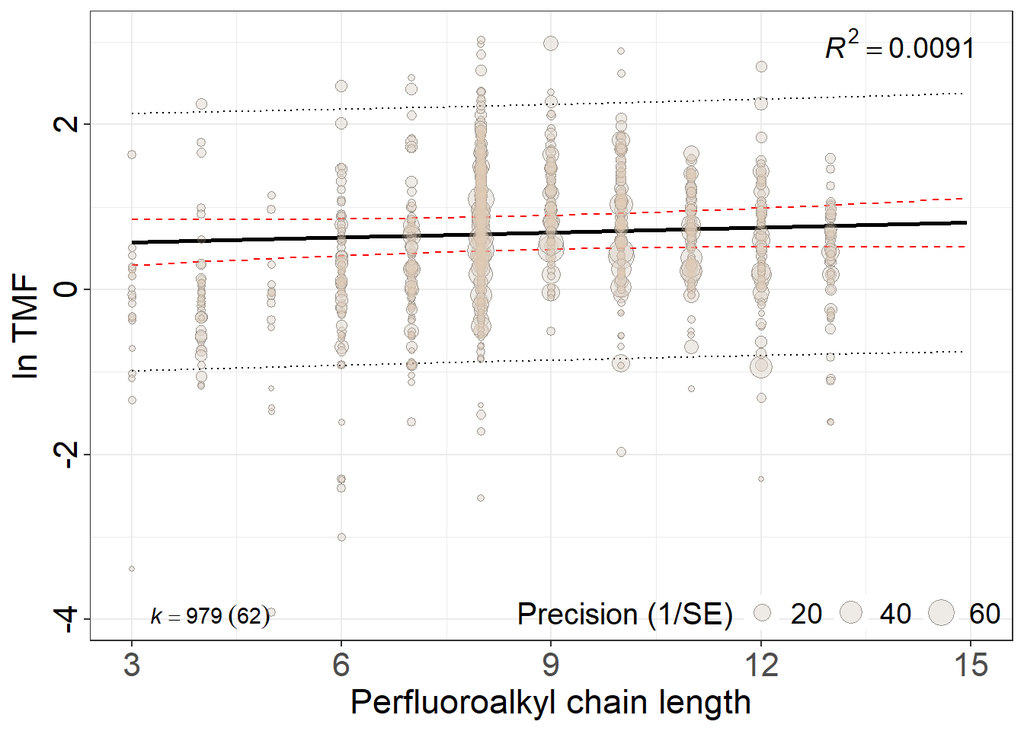

```r
r2_p_ccl <- r2_ml(p_ccl_model, TMF_data2_p_ccl)

p_ccl_bubble <- orchaRd::mod_results(p_ccl_model,
                                   mod = "perfluoroalkyl_ccl",
                                   group = "Study_ID")


figS3 <- bubble_plot(p_ccl_bubble,
            mod = "perfluoroalkyl_ccl",
            group = "Study_ID",
            x = "perfluoroalkyl_ccl",
            y = "ln_TMF",
            est.lwd = 1,
            legend.pos = "bottom.right",
            k.pos = "bottom.left",
            ci.col = "red",
            pi.col = "black",
            est.col = "black",
            g = TRUE) +
  geom_point(data = TMF_data2_p_ccl, aes(x = perfluoroalkyl_ccl,
                                   y = ln_TMF,
                                   size = 1/ln_TMF_se),
             color = "#DDC9B4",
             alpha = 0.2) +
  annotate(geom ="text",
           x = 14,
           y = 3,
           label = paste0("italic(R)^{2} == ", round(r2_p_ccl[1],4)),
           color = "black",
           parse = TRUE,
           size = 5) +
  #ggtitle("E") +
  theme(plot.title = element_text(face = "bold", size = 18),
        legend.title = element_text(size = 15),
        legend.text = element_text(size = 14),
        axis.title.x = element_text(size = 17),
        axis.title.y = element_text(size = 17),
        axis.text.y = element_text(size = 16),
        axis.text.x = element_text(size = 16)) +
  xlab("Perfluoroalkyl chain length") +
  ylab("ln TMF") +
  scale_x_continuous(limits = c(3, 15), breaks = seq(3, 15, by = 3))

figS3
```

### PFAS class

```r
class_model <- run_model(TMF_data2_class, ~ Class-1)

save(class_model, file = here("Rmodels", "class_model.RData"))
```

```r
load(here("Rmodels", "class_model.RData"))
summary(class_model)
```

```
##
## Multivariate Meta-Analysis Model (k = 977; method: REML)
##
##     logLik    Deviance         AIC         BIC        AICc
## -1000.2143   2000.4287   2016.4287   2055.4718   2016.5781
##
## Variance Components:
##
##             estim    sqrt  nlvls  fixed    factor
## sigma^2.1  0.1765  0.4201     62     no  Study_ID
## sigma^2.2  0.0750  0.2739    111     no     FW_ID
## sigma^2.3  0.1935  0.4399     73     no   PFAS_ID
## sigma^2.4  0.1694  0.4116    977     no    TMF_ID
##
## Test for Residual Heterogeneity:
## QE(df = 973) = 24532.4909, p-val < .0001
##
## Test of Moderators (coefficients 1:4):
## F(df1 = 4, df2 = 973) = 11.4470, p-val < .0001
##
## Model Results:
##
##                  estimate      se    tval   df    pval   ci.lb   ci.ub
## ClassEmerging      0.7181  0.2724  2.6360  973  0.0085  0.1835  1.2527   **
## ClassPFCAs         0.6609  0.1423  4.6461  973  <.0001  0.3818  0.9401  ***
## ClassPFSAs         0.8186  0.1592  5.1420  973  <.0001  0.5062  1.1310  ***
## ClassPrecursors    0.6347  0.1433  4.4284  973  <.0001  0.3535  0.9160  ***
##
## ---
## Signif. codes:  0 '***' 0.001 '**' 0.01 '*' 0.05 '.' 0.1 ' ' 1
```

```r
r2_class <- r2_ml(class_model, TMF_data2_class)

fig4C <- orchard_plot_new2(class_model,
             transfm="percent",
             mod = "Class",
             group = "Study_ID",
             xlab = "ln_TMF",
             legend.pos = "bottom.right",
             k.pos = "left",
             angle = 0,
             alpha = 0.4,
             colour = "black",
             fill = FALSE,
             trunk.size = 0.4,
             branch.size = 0.7,
             twig.size = 0.2) +
  annotate(geom = "text",
           x = 4.4,
           y = 9,
           label = paste0("italic(R)^{2} == ", round(r2_class[1],4)),
           color ="black",
           parse = TRUE,
           size = 1.8) +
  #ggtitle("c)")+
  theme(plot.title = element_text(face = "bold", size = 8),
       legend.title = element_text(size = 5),
        legend.text = element_text(size = 5),
       legend.position = c(1, 0.18),
       legend.key = element_blank(),
        legend.key.size = unit(0.3, "cm"),
        axis.title.x = element_text(size = 7),
       #axis.title.x = element_blank(),
        axis.title.y = element_text(size = 7),
        axis.text.y = element_text(size = 6),
       axis.text.x = element_text(size = 6)) +
  scale_size(range = c(0.5, 3)) +
  ggtitle("C") +
  xlab("PFAS class") +
  ylab("TMF") +
  #scale_y_break(c(11, 13)) +
  scale_y_continuous(limits = c(0, 14), breaks = seq(0, 14, by = 1)) +
  scale_fill_manual(values = c("#66101F", "#597802", "#114B5F", "#FB8B24")) +
  scale_color_manual(values = c("#66101F", "#597802", "#114B5F", "#FB8B24"))
```

## Chemicals’ regulation status

```r
regulation_model <- run_model(plot_data4, ~ regulation -1)
save(regulation_model, file = here("Rmodels", "regulation_model.RData"))
```

```r
load(here("Rmodels", "regulation_model.RData"))
summary(regulation_model)
```

```
##
## Multivariate Meta-Analysis Model (k = 844; method: REML)
##
##    logLik   Deviance        AIC        BIC       AICc
## -836.1714  1672.3429  1686.3429  1719.4850  1686.4774
##
## Variance Components:
##
##             estim    sqrt  nlvls  fixed    factor
## sigma^2.1  0.1590  0.3988     61     no  Study_ID
## sigma^2.2  0.0768  0.2772    110     no     FW_ID
## sigma^2.3  0.1483  0.3852     18     no   PFAS_ID
## sigma^2.4  0.1610  0.4012    844     no    TMF_ID
##
## Test for Residual Heterogeneity:
## QE(df = 841) = 20648.8593, p-val < .0001
##
## Test of Moderators (coefficients 1:3):
## F(df1 = 3, df2 = 841) = 11.0202, p-val < .0001
##
## Model Results:
##
##                   estimate      se    tval   df    pval    ci.lb   ci.ub
## regulationnone      0.4600  0.2351  1.9571  841  0.0507  -0.0013  0.9214    .
## regulationREACH     0.5848  0.1686  3.4695  841  0.0005   0.2540  0.9157  ***
## regulationSCPoPs    0.8605  0.1684  5.1106  841  <.0001   0.5300  1.1909  ***
##
## ---
## Signif. codes:  0 '***' 0.001 '**' 0.01 '*' 0.05 '.' 0.1 ' ' 1
```

```r
r2_regulation <- r2_ml(regulation_model, plot_data4)
predict.rma(regulation_model, newmods = c(1, 0, -1), transf = exp, addx = T)
```

```
##
##    pred  ci.lb  ci.ub  pi.lb  pi.ub X.regulationnone X.regulationREACH
##  0.6700 0.3957 1.1347 0.1433 3.1317                1                 0
##  X.regulationSCPoPs
##                  -1
```

```r
predict.rma(regulation_model, newmods = c(1, -1, 0), transf = exp, addx = T)
```

```
##
##    pred  ci.lb  ci.ub  pi.lb  pi.ub X.regulationnone X.regulationREACH
##  0.8827 0.5224 1.4913 0.1890 4.1224                1                -1
##  X.regulationSCPoPs
##                   0
```

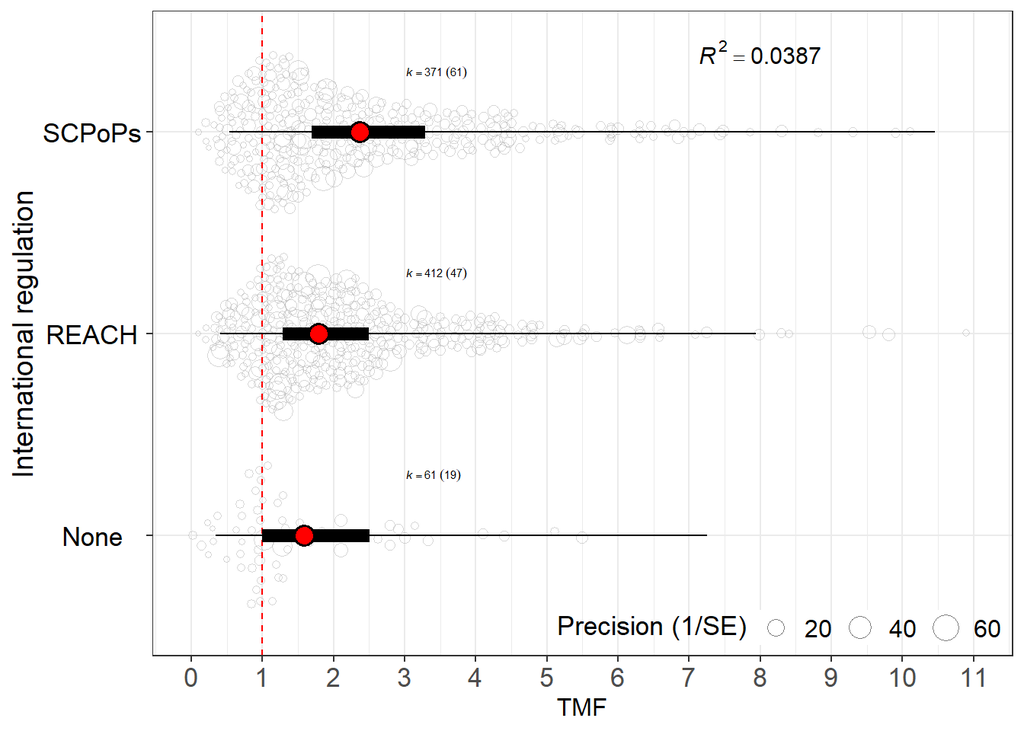

```r
figS14 <- orchard_plot_new(regulation_model,
             transfm = "percent",
             mod = "regulation",
             group = "Study_ID",
             xlab = "ln_TMF",
             legend.pos = "bottom.right",
             k.pos = "left",
             angle = 0,
             colour = "black",
             fill = FALSE,
             trunk.size = 1,
             branch.size = 3.1,
             twig.size = 0.5) +
  annotate(geom = "text",
           x = 3.4,
           y = 8,
           label = paste0("italic(R)^{2} == ", round(r2_regulation[1],4)),
           color ="black",
           parse = TRUE,
           size = 4) +
  #ggtitle("c)")+
  theme(#plot.title = element_text(face = "bold", size = 16),
       legend.title = element_text(size = 13),
        legend.text = element_text(size = 12),
        axis.title.x = element_text(size = 12),
        axis.title.y = element_text(size = 14),
        axis.text.y = element_text(size = 13),
       axis.text.x = element_text(size = 13)) +
  #ggtitle("C") +
  xlab("International regulation") +
  ylab("TMF") +
  #scale_y_break(c(11, 13)) +
  scale_y_continuous(limits = c(0, 11), breaks = seq(0, 11, by = 1))

figS14
```

# Full model

```r
VCV_fmodel <- vcalc(vi = TMF_data_fmodel$ln_TMF_se^2,
             cluster = TMF_data_fmodel$FW_ID,
             obs = TMF_data_fmodel$TMF_ID,
             rho = 0.5)
```

```r
full_model <- rma.mv(yi = ln_TMF,
                     V = VCV_fmodel,
                     mods = ~  1 +
                       Sample_type +
                       Conc_determ_method +
                       TEF +
                       Breathing_type_fw +
                       Breathing_type +
                       Class +
                       scale(Latitude_abs) +
                       scale(ccl),
                     random = list(~1|Study_ID,
                                   ~1|FW_ID,
                                   ~1|PFAS_ID,
                                   ~1|TMF_ID
                                   ),
                     test = "t",
                     data = TMF_data_fmodel,
                     sparse = TRUE)

save(full_model, file = here("Rmodels", "full_model.RData"))
```

```r
load(here("Rmodels", "full_model.RData"))
summary(full_model)
```

```
##
## Multivariate Meta-Analysis Model (k = 761; method: REML)
##
##    logLik   Deviance        AIC        BIC       AICc
## -731.3541  1462.7082  1506.7082  1608.1435  1508.1137
##
## Variance Components:
##
##             estim    sqrt  nlvls  fixed    factor
## sigma^2.1  0.4175  0.6461     42     no  Study_ID
## sigma^2.2  0.0210  0.1450     76     no     FW_ID
## sigma^2.3  0.2143  0.4629     65     no   PFAS_ID
## sigma^2.4  0.1462  0.3824    761     no    TMF_ID
##
## Test for Residual Heterogeneity:
## QE(df = 743) = 12428.6940, p-val < .0001
##
## Test of Moderators (coefficients 2:18):
## F(df1 = 17, df2 = 743) = 3.2953, p-val < .0001
##
## Model Results:
##
##                                        estimate      se     tval   df    pval
## intrcpt                                  0.4289  0.5686   0.7542  743  0.4510
## Sample_typespecific tissues              0.2101  0.3061   0.6865  743  0.4926
## Sample_typemixed                         0.4637  0.1135   4.0864  743  <.0001
## Conc_determ_methodNot normalized         0.3312  0.0770   4.3015  743  <.0001
## TEF2.4                                  -0.5156  0.9423  -0.5472  743  0.5844
## TEF2.4; 3.3                             -0.4540  0.8679  -0.5231  743  0.6011
## TEF2.88                                 -0.0339  0.8857  -0.0383  743  0.9695
## TEF3.3                                  -0.1702  1.0184  -0.1671  743  0.8673
## TEF3.4                                   0.3415  0.5042   0.6774  743  0.4984
## TEF3.4; 2.4                              0.3230  0.8167   0.3955  743  0.6926
## TEF3.8                                   0.1349  0.4683   0.2880  743  0.7734
## Breathing_type_fwwater breathing only   -0.8059  0.3561  -2.2634  743  0.0239
## Breathing_typeWater breathing           -0.3120  0.2351  -1.3271  743  0.1849
## ClassPFCA                               -0.1594  0.3223  -0.4946  743  0.6210
## ClassPFSA                                0.1240  0.3193   0.3883  743  0.6979
## ClassPrecursor/intermediate             -0.1656  0.3043  -0.5442  743  0.5865
## scale(Latitude_abs)                      0.0199  0.1141   0.1748  743  0.8613
```

[output cut: 8 more lines]

```
## TEF2.88                                -1.7726   1.7049
## TEF3.3                                 -2.1694   1.8290
## TEF3.4                                 -0.6483   1.3314
## TEF3.4; 2.4                            -1.2803   1.9262
## TEF3.8                                 -0.7844   1.0541
## Breathing_type_fwwater breathing only  -1.5050  -0.1069    *
## Breathing_typeWater breathing          -0.7735   0.1495
## ClassPFCA                              -0.7920   0.4732
## ClassPFSA                              -0.5028   0.7507
## ClassPrecursor/intermediate            -0.7630   0.4318
## scale(Latitude_abs)                    -0.2040   0.2438
## scale(ccl)                             -0.0601   0.2474
##
## ---
## Signif. codes:  0 '***' 0.001 '**' 0.01 '*' 0.05 '.' 0.1 ' ' 1
```

```r
r2_ml(full_model, TMF_data_fmodel)
```

```
##    R2_marginal R2_conditional
##      0.1843339      0.8507186
```

# Model selection

```r
eval(metafor:::.MuMIn) # use eval() function to extract helper functions from MuMIn and make them usable in metafor.
mod.candidate <- dredge(full_model, beta = "none", evaluate = TRUE, rank = "AICc", trace=2) # dredge to produce all possible candidate models

# Save the candidate models
save(mod.candidate, file = here("Rmodels", "mod_candidate.RData"))
```

```r
# Next step, let’s select a sets of best models.
load(here("Rmodels", "mod_candidate.RData"))
subset(mod.candidate, delta <= 4, recalc.weights = FALSE)
```

[output not shown]

```r
# Sum of weights for each variable included in the mod.candidate
sw(mod.candidate)
```

[output not shown]

```r
weights <- read_csv(here("Rdata", "aic_weights.csv")) #upload data from sw(mod.candidate)
```

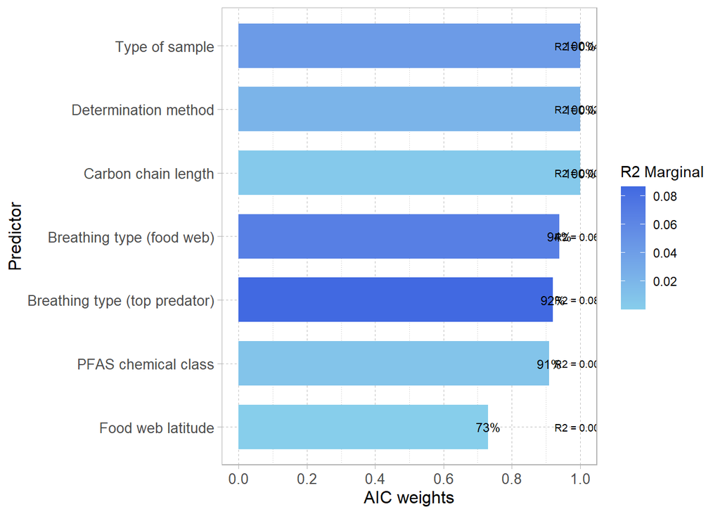

```r
weights <- weights %>%
  mutate(weights_percentage = round( Sum_of_weights * 100))

weights$Predictor <- factor(weights$Predictor, levels = weights$Predictor[order(weights$weights_percentage, weights$R2_marginal)])


figS16 <- ggplot(weights, aes(Predictor, Sum_of_weights)) +
  geom_col(aes(fill = R2_marginal), width = 0.7) +  # Gradient fill based on R2_marginal
  geom_text(aes(label = paste0(weights_percentage, "%"), x = Predictor),
            position = position_stack(vjust = 0.5),
            size = 3) +
  geom_text(aes(label = paste("R2 =", sprintf("%.3f", R2_marginal)), x = Predictor, y = max(Sum_of_weights)),
            position = position_stack(vjust = 1.07),
            size = 2.5, color = "black") +
  theme_light() +
  coord_flip() +
  scale_fill_gradient(low = "skyblue", high = "royalblue", name = "R2 Marginal") +  # Color gradient
  scale_x_discrete(name = "Predictor") +
  scale_y_continuous(name = "AIC weights",
                     breaks = seq(0, 1, by = 0.2)) +
  theme(legend.position = "right",  # Move legend to the right
        axis.title.x = element_text(size = 12),
        axis.title.y = element_text(size = 12),
        axis.text = element_text(size = 10),
        panel.grid.major = element_line(color = "grey",
                                        linewidth = 0.2,
                                        linetype = "dashed"),
        panel.grid.minor = element_line(color = "grey",
                                        linewidth = 0.2,
                                        linetype = "dotted"))
figS16
```

# Risk of Bias assessment

```r
TMF_data2_RoB <- TMF_data2 %>%
  filter(!if_any(c(Selection_bias, Measurement_bias, Reporting_bias, Funding_bias), ~ . == "High risk"))

VCV_RoB <- vcalc(vi = TMF_data2_RoB$ln_TMF_se^2,
             cluster = TMF_data2_RoB$FW_ID,
             obs = TMF_data2_RoB$TMF_ID,
             rho = 0.5)
```

```r
mod_RoB <- rma.mv(yi = ln_TMF, # Natural logarithm of the Trophic Magnification Factor
              V = VCV_RoB, # Variance co-variance matrix
              random = list(~1|Study_ID,
                            ~1|FW_ID,
                            ~1|PFAS_ID,
                            ~1|TMF_ID
                            ),
              test = "t",
              sparse = T,
              data = TMF_data2_RoB)

save(mod_RoB, file = here("Rmodels", "mod_RoB.RData"))
```

```r
load(here("Rmodels", "mod_RoB.RData"))
summary(mod_RoB)
```

```
##
## Multivariate Meta-Analysis Model (k = 651; method: REML)
##
##    logLik   Deviance        AIC        BIC       AICc
## -694.0360  1388.0719  1398.0719  1420.4568  1398.1651
##
## Variance Components:
##
##             estim    sqrt  nlvls  fixed    factor
## sigma^2.1  0.2405  0.4904     32     no  Study_ID
## sigma^2.2  0.0313  0.1768     67     no     FW_ID
## sigma^2.3  0.3282  0.5729     60     no   PFAS_ID
## sigma^2.4  0.2023  0.4498    651     no    TMF_ID
##
## Test for Heterogeneity:
## Q(df = 650) = 24412.4540, p-val < .0001
##
## Model Results:
##
## estimate      se    tval   df    pval   ci.lb   ci.ub
##   0.6012  0.1405  4.2794  650  <.0001  0.3253  0.8770  ***
##
## ---
## Signif. codes:  0 '***' 0.001 '**' 0.01 '*' 0.05 '.' 0.1 ' ' 1
```

```r
i2_ml(mod_RoB)
```

```
##    I2_Total I2_Study_ID    I2_FW_ID  I2_PFAS_ID   I2_TMF_ID
##   98.794032   29.613702    3.848822   40.420270   24.911237
```

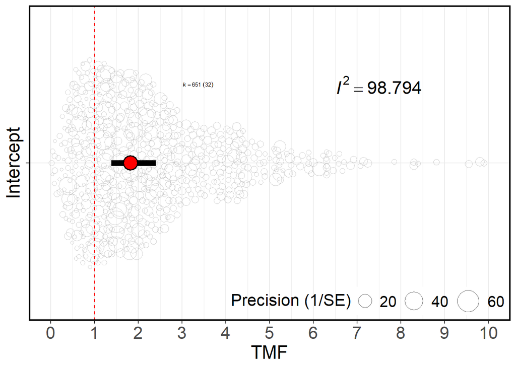

```r
I2_mod_RoB <- orchaRd::i2_ml(mod_RoB)
figS21 <- orchard_plot_new(mod_RoB,
                        transfm = "percent",
                        mod = "1",
                        group = "Study_ID",
                        xlab = "ln_TMF",
                        k.pos = "left",
                        alpha = 0.6,
                        trunk.size = 1.5,
                        branch.size = 2.7,
                        twig.size = 0.4,
                        colour = FALSE,
                        fill = FALSE) +
  annotate(geom = "text",
           x = 1.3,
           y = 7.5,
           label = paste0("italic(I)^{2} == ", round(I2_mod_RoB[1],4)),
           size = 6,
           color ="black",
           parse = TRUE) +
  scale_size_continuous(range = c(1, 10)) + # change point scaling
  theme(panel.border = element_rect(colour = "black",
                                    fill = NA,
                                    size = 1.3),
       legend.title = element_text(size = 16),
        legend.text = element_text(size = 15),
        axis.title.x = element_text(size = 18),
        axis.title.y = element_text(size = 18),
        axis.text.y = element_blank(),
       axis.text.x = element_text(size = 17)) +
  #ylim(NA, 10) +
  xlab("Intercept") +
  ylab("TMF") +
  scale_y_continuous(limits = c(0, 10), breaks = seq(0, 10, by = 1))

figS21
```

# Publication bias

## Visual inspection - Funnel plot

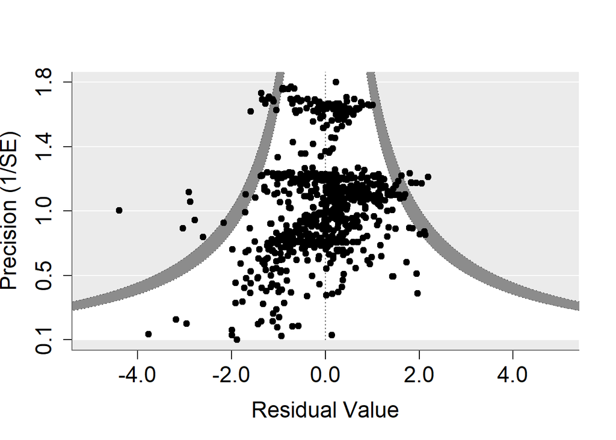

```r
# Increase text size for x and y axes
par(cex.axis = 1.5)

# Increase label size for x and y axes
par(cex.lab = 1.5)

figS17 <- funnel(
  full_model,
  yaxis = "seinv", # Inverse of standard error (precision) as the y axis
  level = c(90, 95),  # levels of statistical significance highlighted
  shade = c("white", "gray55"), # shades for different levels of statistical significance
  back = "#EBEBEB",
  legend = FALSE, # display legend
  ylab = "Precision (1/SE)",
  cex.lab = 1.5,
  digits = 1,
  xlim = c(-5,5)
  )
```

## Small study effect

```r
mod_se <- rma.mv(ln_TMF,
                     VCV,
                     mods = ~ ln_TMF_se,
                     random = list(~1|Study_ID,
                                   ~1|FW_ID,
                                   ~1|PFAS_ID,
                                   ~1|TMF_ID
                                   ),
                     method = "REML",
                     test = "t",
                     data = TMF_data2
                     )

save(mod_se, file = here("Rmodels", "mod_se.RData"))
summary(mod_se)
# mod_pb <- rma.mv(ln_TMF,
#                  VCV,
#                      method = "REML",
#                      test = "t",
#                      data = TMF_data2
#                      )
#
#
# robust(mod_pb, cluster = FW_ID, clubSandwich = T)
```

```r
load(here("Rmodels", "mod_se.RData"))
summary(mod_se)
```

```
##
## Multivariate Meta-Analysis Model (k = 1009; method: REML)
##
##     logLik    Deviance         AIC         BIC        AICc
## -1021.9129   2043.8257   2055.8257   2085.3141   2055.9097
##
## Variance Components:
##
##             estim    sqrt  nlvls  fixed    factor
## sigma^2.1  0.1674  0.4091     64     no  Study_ID
## sigma^2.2  0.0814  0.2853    117     no     FW_ID
## sigma^2.3  0.1605  0.4007     77     no   PFAS_ID
## sigma^2.4  0.1650  0.4062   1009     no    TMF_ID
##
## Test for Residual Heterogeneity:
## QE(df = 1007) = 25525.4107, p-val < .0001
##
## Test of Moderators (coefficient 2):
## F(df1 = 1, df2 = 1007) = 22.7432, p-val < .0001
##
## Model Results:
##
##            estimate      se     tval    df    pval    ci.lb    ci.ub
## intrcpt      0.9202  0.1091   8.4354  1007  <.0001   0.7061   1.1342  ***
## ln_TMF_se   -0.5425  0.1138  -4.7690  1007  <.0001  -0.7657  -0.3193  ***
##
## ---
## Signif. codes:  0 '***' 0.001 '**' 0.01 '*' 0.05 '.' 0.1 ' ' 1
```

```
## Ignoring unknown labels:
## • parse : "TRUE"
```

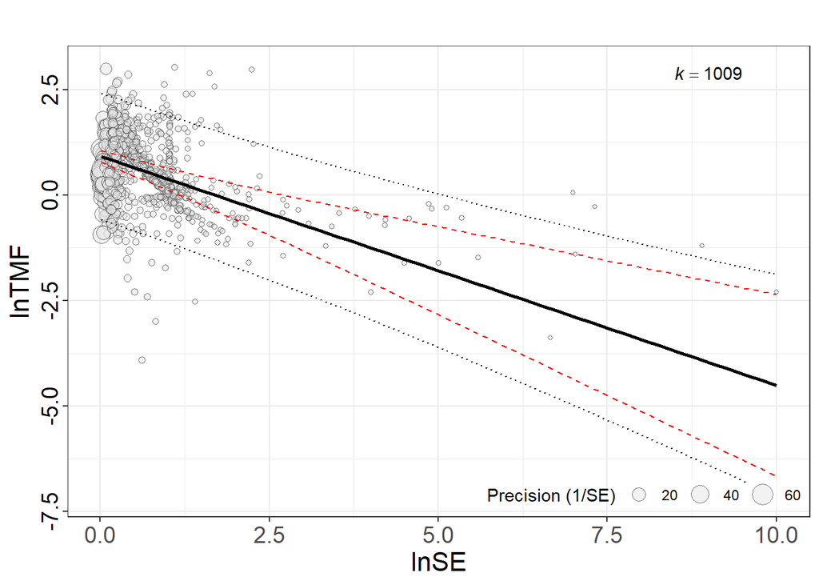

```r
sse_bubble <- orchaRd::mod_results(mod_se,
                                  mod = "ln_TMF_se",
                                  group = "Study_ID",
                                  data = TMF_data2)

figS18 <- orchaRd::bubble_plot(sse_bubble,
                     group = "Study_ID",
                     mod = "ln_TMF_se",
            legend.pos = "bottom.right",
            k.pos = "top.right",
            ci.col = "red",
            pi.col = "black",
            est.col = "black") +
  ggtitle("") +
  theme(plot.title = element_text(size = 18),
        axis.title.x = element_text(size = 16),
        axis.title.y = element_text(size = 16),
        axis.text.y = element_text(size = 14),
        axis.text.x = element_text(size = 14)) +
  xlab("lnSE") +
  ylab("lnTMF")

figS18
```

## Time-lag bias

```r
MLMR_mod_year.c <- metafor::rma.mv(ln_TMF,
                            VCV,
                            mods = ~ scale(year_publication),
                            random = list(~1|Study_ID,
                                          ~1|FW_ID,
                                          ~1|PFAS_ID,
                                          ~1|TMF_ID
                                          ),
                            test = "t",
                            sparse = T,
                            data = TMF_data2)

save(MLMR_mod_year.c, file = here("Rmodels", "MLMR_mod_year.c.RData"))
```

```r
load(here("Rmodels", "MLMR_mod_year.c.RData"))
summary(MLMR_mod_year.c)
```

```
##
## Multivariate Meta-Analysis Model (k = 1009; method: REML)
##
##     logLik    Deviance         AIC         BIC        AICc
## -1033.5536   2067.1071   2079.1071   2108.5955   2079.1911
##
## Variance Components:
##
##             estim    sqrt  nlvls  fixed    factor
## sigma^2.1  0.1753  0.4187     64     no  Study_ID
## sigma^2.2  0.0774  0.2782    117     no     FW_ID
## sigma^2.3  0.1786  0.4226     77     no   PFAS_ID
## sigma^2.4  0.1655  0.4068   1009     no    TMF_ID
##
## Test for Residual Heterogeneity:
## QE(df = 1007) = 25104.9675, p-val < .0001
##
## Test of Moderators (coefficient 2):
## F(df1 = 1, df2 = 1007) = 0.0041, p-val = 0.9490
##
## Model Results:
##
##                          estimate      se     tval    df    pval    ci.lb
## intrcpt                    0.6977  0.1015   6.8771  1007  <.0001   0.4986
## scale(year_publication)   -0.0046  0.0727  -0.0639  1007  0.9490  -0.1472
##                           ci.ub
## intrcpt                  0.8968  ***
## scale(year_publication)  0.1379
##
## ---
## Signif. codes:  0 '***' 0.001 '**' 0.01 '*' 0.05 '.' 0.1 ' ' 1
```

```r
r2_pbias <- r2_ml(MLMR_mod_year.c, TMF_data2)
pb_bubble <- orchaRd::mod_results(MLMR_mod_year.c,
                                  mod = "year_publication",
                                  group = "Study_ID",
                                  data = dat)

fig5F <- bubble_plot_new(pb_bubble,
                     group = "Study_ID",
                     mod = "year_publication",
            legend.pos = "bottom.right",
            k.pos = "bottom.left",
            ci.col = "red",
            pi.col = "black",
            est.col = "black",
            g = TRUE) +
  annotate(geom ="text",
           x = 2017,
           y = 3,
           label = paste0("italic(R)^{2} == ", round(r2_pbias[1],4)),
           color = "black",
           parse = TRUE,
           size = 2) +
  ggtitle("F") +
  theme(plot.title = element_text(face = "bold", size = 9),
        legend.title = element_text(size = 6),
        legend.text = element_text(size = 6),
        legend.key = element_blank(),
        legend.key.size = unit(0.3, "cm"),
        axis.title.x = element_text(size = 8),
        axis.title.y = element_blank(),
        axis.text.y = element_blank(),
        axis.text.x = element_text(size = 7)) +
  scale_size(range = c(0.5, 3)) +
  xlab("Publication year") +
  ylab("ln TMF") +
  scale_x_continuous(breaks = seq(2003, 2024, by = 5), limits = c(2003, 2024))
```

## Leave-one-out-analysis

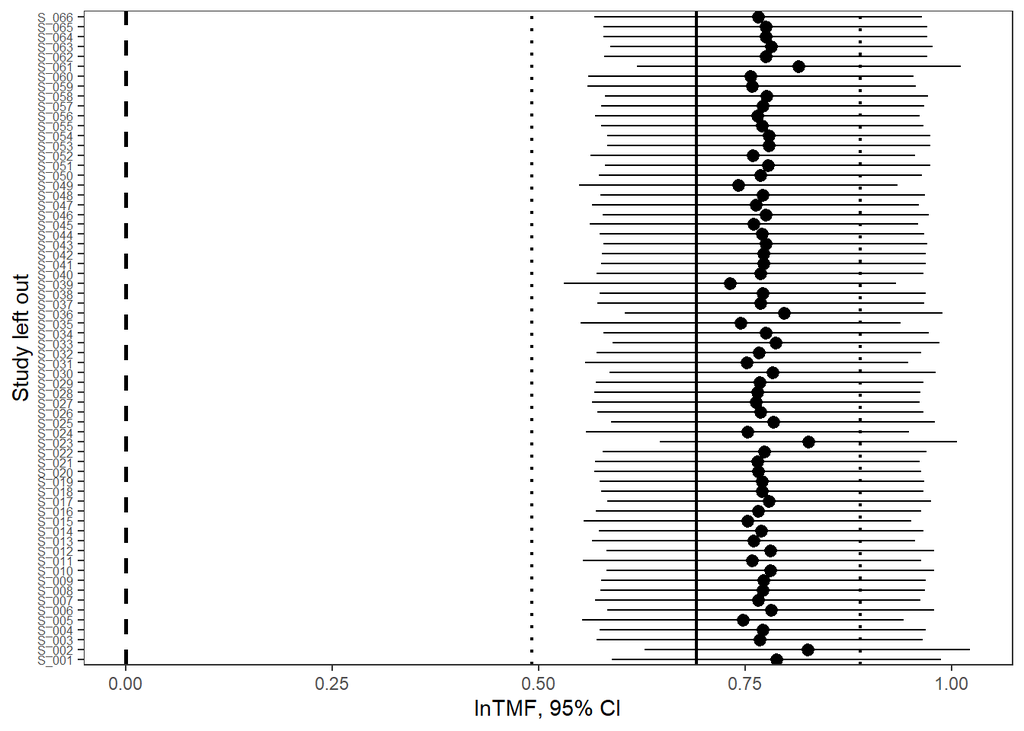

```r
MA_oneout <- readRDS(here("Rdata", "MA_oneout.RDS"))

# plotting
figS19 <- ggplot(MA_oneout) + geom_hline(yintercept = 0, lty = 2, lwd = 1) +

  geom_hline(yintercept = mod$ci.lb, lty = 3, lwd = 0.75, colour = "black") +
  geom_hline(yintercept = mod$b, lty = 1, lwd = 0.75, colour = "black") +
  geom_hline(yintercept = mod$ci.ub,
             lty = 3, lwd = 0.75, colour = "black") +
  geom_pointrange(aes(x = left_out, y = est,
                      ymin = lower, ymax = upper)) +
  xlab("Study left out") +
  ylab("lnTMF, 95% CI") +
  coord_flip() +
  theme(panel.grid.minor = element_blank()) + theme_bw() + theme(panel.grid.major = element_blank()) +
  theme(panel.grid.minor.x = element_blank()) + theme(axis.text.y = element_text(size = 6))

figS19
```